# Aplicacion de la IA en el diseño de cruzamiento dirigidos. Variable padre

Gonzalo Rivera

2023-07-07

# 1. INTRODUCCIÓN

En este caso vamos a llevar a cabo los analisis para los modelos de clasificacion binaria, es decir, realizaremos los modelos siguiendo dos planteamiento, el primero seria ver si el modelo es capaz de diferenciar entre un cruce y el resto, el segundo planteamiento seria ver si podemos diferenciar entre dos cruces concretos.

# 2. PREPROCESADO DE DATOS

Primero vamos a limpiar de NA.

```r
library(readxl)
datosp <- read_excel("C:/Users/gonza/Documents/TFM/data/datosred.xlsx")
```

```r
library(mice)
```

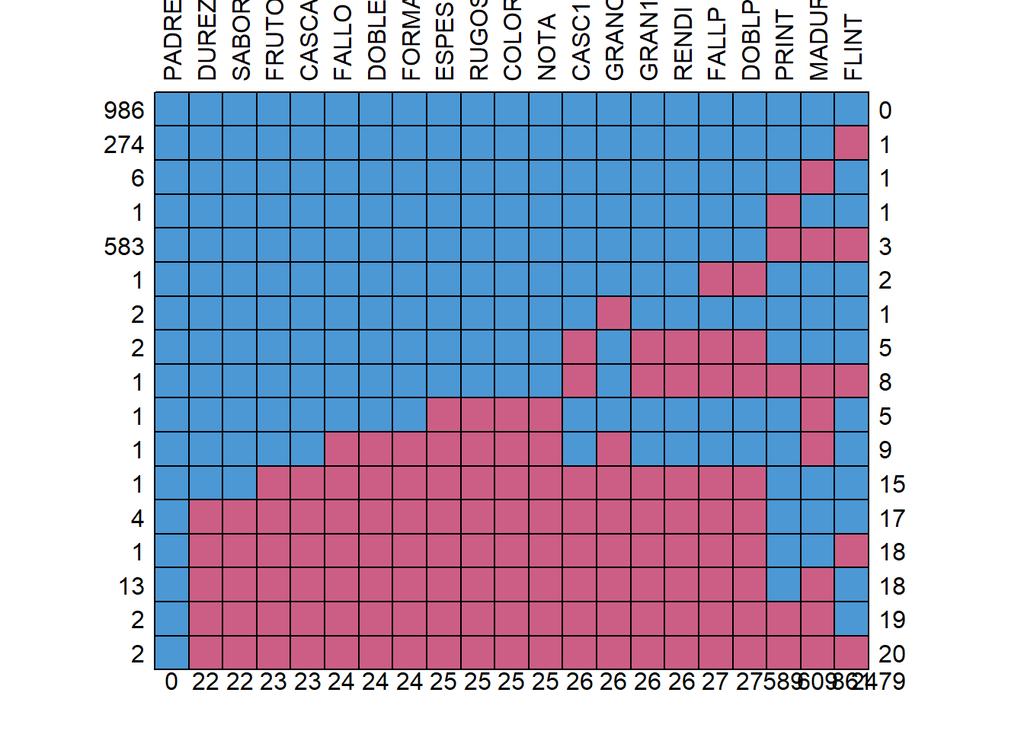

```
##     PADRE DUREZ SABOR FRUTO CASCA FALLO DOBLE FORMA ESPES RUGOS COLOR NOTA
## 986     1     1     1     1     1     1     1     1     1     1     1    1
## 274     1     1     1     1     1     1     1     1     1     1     1    1
## 6       1     1     1     1     1     1     1     1     1     1     1    1
## 1       1     1     1     1     1     1     1     1     1     1     1    1
## 583     1     1     1     1     1     1     1     1     1     1     1    1
## 1       1     1     1     1     1     1     1     1     1     1     1    1
## 2       1     1     1     1     1     1     1     1     1     1     1    1
## 2       1     1     1     1     1     1     1     1     1     1     1    1
## 1       1     1     1     1     1     1     1     1     1     1     1    1
## 1       1     1     1     1     1     1     1     1     0     0     0    0
## 1       1     1     1     1     1     0     0     0     0     0     0    0
## 1       1     1     1     0     0     0     0     0     0     0     0    0
## 4       1     0     0     0     0     0     0     0     0     0     0    0
## 1       1     0     0     0     0     0     0     0     0     0     0    0
```

[output cut: 23 more lines]

```r
library(forcats)
datap <- datosp[, c("PADRE", "FLINT", "PRINT", "MADUR", "FRUTO", "CASCA", "CASC1", "DUREZ", "GRANO", "GRAN1", "RENDI", "FALLO", "FALLP", "DOBLE", "DOBLP", "FORMA", "ESPES", "RUGOS", "COLOR", "SABOR", "NOTA")]
md.pattern(datap,rotate.names = T)
```

```r
library(dplyr)
datospred <- datap[complete.cases(datap), ]
table(datospred$PADRE)
```

```
##
##         A1353         A2198      Antoneta       D00i072       D00i078
##             3            96            93            12            41
##       D00i203       D01i188       D01i203       D01i466       D01i467
##             6            10            12            63            43
##       D01i560       D98i672       D98i694       D98i707       Desmayo
##             8            44            19            43            22
## FerrxTuono283      Lauranne       Marcona         Marta     Nonpareil
##             4            37           133            88             9
##     Pscoparia        Pwebbi         R1000     Ramillete         S5133
##             3            33           101            33            30
```

# 3. GENERACION DE MODELOS MULTIPLES PARA PADRE

Seleccionamos los padres con mas de 15 observaciones

```r
# Calcular el recuento de observaciones por cruce
recuentopadre <- table(datospred$PADRE)

# Obtener los cruces con más de 15 observaciones
padressel <- names(recuentopadre)[recuentopadre > 15]

# Crear un nuevo conjunto de datos con los cruces seleccionados
datospr <- datospred[datospred$PADRE %in% padressel, ]
```

```r
datospr$PADRE <- as.factor(datospr$PADRE)
table(datospr$PADRE)
```

```
##
##     A2198  Antoneta   D00i078   D01i466   D01i467   D98i672   D98i694   D98i707
##        96        93        41        63        43        44        19        43
##   Desmayo  Lauranne   Marcona     Marta    Pwebbi     R1000 Ramillete     S5133
##        22        37       133        88        33       101        33        30
```

```r
str(datospr)
```

```
## tibble [919 × 21] (S3: tbl_df/tbl/data.frame)
##  $ PADRE: Factor w/ 16 levels "A2198","Antoneta",..: 14 14 14 14 14 14 14 14 14 14 ...
##  $ FLINT: num [1:919] 3 3 3 3 2 2 3 3 3 2 ...
##  $ PRINT: num [1:919] 2 3 1 3 1 1 2 1 2 1 ...
##  $ MADUR: num [1:919] 221 235 224 208 208 214 211 208 214 207 ...
##  $ FRUTO: num [1:919] 25 25 25 25 25 25 25 20 25 25 ...
##  $ CASCA: num [1:919] 83 44 50 69 77 40 53 30 69 69 ...
##  $ CASC1: num [1:919] 3.32 1.76 2.12 2.76 3.11 ...
##  $ DUREZ: num [1:919] 5 2 2 4 4 2 3 2 4 4 ...
##  $ GRANO: num [1:919] 23 23 22 23 18 14 23 12 19 22 ...
##  $ GRAN1: num [1:919] 0.92 0.92 1 0.92 0.75 ...
##  $ RENDI: num [1:919] 27.7 52.3 47.2 33.3 24.1 ...
##  $ FALLO: num [1:919] 0 0 3 0 1 8 1 5 0 1 ...
##  $ FALLP: num [1:919] 0 0 12 0 4 32 4 25 0 4 ...
##  $ DOBLE: num [1:919] 0 1 0 14 0 0 0 0 0 3 ...
##  $ DOBLP: num [1:919] 0 4 0 56 0 0 0 0 0 12 ...
##  $ FORMA: num [1:919] 11 5 4 4 8 7 8 1 5 4 ...
##  $ ESPES: num [1:919] 2 3 2 2 2 1 2 2 3 2 ...
##  $ RUGOS: num [1:919] 1 1 2 2 2 1 3 2 2 2 ...
##  $ COLOR: num [1:919] 2 4 2 1 1 2 3 3 2 2 ...
##  $ SABOR: num [1:919] 3 3 3 2 3 3 3 3 3 3 ...
##  $ NOTA : num [1:919] 3 3 3 2 2 2 3 1 2 3 ...
```

Ahora visualizamos de forma grafica el numero de niveles por padre

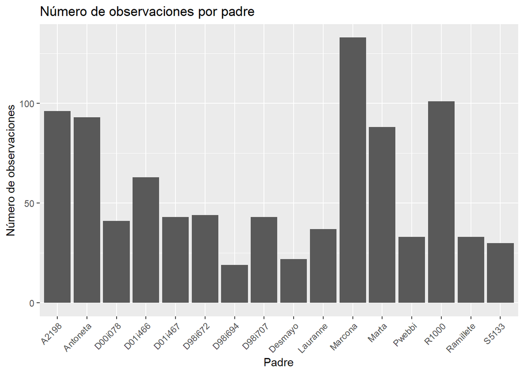

```r
library(ggplot2)
ggplot(datospr, aes(x = PADRE)) +
  geom_bar() +
  labs(x = "Padre", y = "Número de observaciones", title = "Número de observaciones por padre") +
  theme(axis.text.x = element_text(angle = 45, hjust = 1))
```

## 3.1 SELECCION DE VARIABLES POR RANDOM FOREST

En este punto podemos llevar a cabo la seleccion de variables para luego comprobar los resultados.

```r
library(caret)
set.seed(12345)
datosppart <- createDataPartition(datospr$PADRE,p=0.8,list = FALSE)
datosp.train <- datospr[datosppart,]
datosp.test <- datospr[-datosppart,]
```

```r
subsets <- c(3:21) #Indicamos que cree subgrupos de entre 3 y 21 variables.

seeds <- vector(mode = "list", length = 6)

for(i in 1:10) seeds[[i]] <- sample.int(1000, length(subsets) + 1)
seeds[[11]] <- sample.int(1000, 1)

ctrl.treebag.rfe.cv.10 <- rfeControl(functions=rfFuncs ,
                                     method = "cv",
                                     number = 10,
                                     seeds = seeds,
                                     returnResamp="final",
                                     verbose = TRUE,
                                     allowParallel = TRUE)
```

```r
treebag.rfe.cv.10padre <- rfe(PADRE~., data=datosp.train,
                         sizes=subsets,
                         rfeControl=ctrl.treebag.rfe.cv.10)
```

Le quitamos el contenido de fit, para que no tenga tanto peso el archivo y guardammos el rds.

```r
treebag.rfe.cv.10padre$fit = NULL
saveRDS(treebag.rfe.cv.10padre, "C:/Users/gonza/Documents/TFM/treebag.fre.cv.10padre.rds")
```

```r
varselecpadre <- readRDS("C:/Users/gonza/Documents/TFM/treebag.fre.cv.10padre.rds")
varselecpadre$optVariables
```

```
##  [1] "MADUR" "GRANO" "GRAN1" "RENDI" "SABOR" "CASC1" "CASCA" "NOTA"  "FORMA"
## [10] "ESPES" "FLINT" "COLOR" "RUGOS" "PRINT" "DUREZ" "DOBLE" "DOBLP" "FALLP"
## [19] "FALLO"
```

## 3.2 GENERACION DE MODELOS MULTIPLES CON DATOS SELECCION DE VARIABLES

```r
datospsv <- datospr[,c("PADRE", "MADUR", "GRAN1", "GRANO", "RENDI", "SABOR", "CASCA", "CASC1", "FORMA", "NOTA", "COLOR", "PRINT", "DUREZ", "ESPES", "RUGOS", "FLINT", "FALLP", "FALLO")]
```

Primero balanceamos los datos

```r
# Crear una tabla con el recuento de los niveles de la variable "padre"
tablapadresv <- table(datospsv$PADRE)

# Encontrar el nivel con el menor número de observaciones
minobspsv <- min(tablapadresv)

# Crear una lista vacía para almacenar los datos balanceados
datosbpadresv <- data.frame()

# Iterar sobre cada nivel de la variable "padre"
for (nivel in levels(datospsv$PADRE)) {
  # Subconjunto de datos para el nivel actual
  datosnivelpsv <- subset(datospsv, PADRE == nivel)

  # Muestreo aleatorio de observaciones para igualar el número mínimo de observaciones
  datosmuestrpsv <- datosnivelpsv[sample(1:nrow(datosnivelpsv), minobspsv), ]

  # Agregar los datos muestreados al conjunto de datos balanceados
  datosbpadresv <- rbind(datosbpadresv, datosmuestrpsv)
}

# Verificar el balance resultante
table(datosbpadresv$PADRE)
```

```
##
##     A2198  Antoneta   D00i078   D01i466   D01i467   D98i672   D98i694   D98i707
##        19        19        19        19        19        19        19        19
##   Desmayo  Lauranne   Marcona     Marta    Pwebbi     R1000 Ramillete     S5133
##        19        19        19        19        19        19        19        19
```

Creamos los datos de entrenamiento y de test.

```r
datospsv.id <- createDataPartition(datosbpadresv$PADRE,p=0.8,list = FALSE)
datospsv.tr <- datosbpadresv[datospsv.id,]
datospsv.te <- datosbpadresv[-datospsv.id,]
datospsv.tr_x <- datospsv.tr
datospsv.tr_x$PADRE=NULL

table(datospsv.tr$PADRE)
```

```
##
##     A2198  Antoneta   D00i078   D01i466   D01i467   D98i672   D98i694   D98i707
##        16        16        16        16        16        16        16        16
##   Desmayo  Lauranne   Marcona     Marta    Pwebbi     R1000 Ramillete     S5133
##        16        16        16        16        16        16        16        16
```

### 3.2.1 Modelo ranger

```r
TrainCtrlRanger.3cv10 <- trainControl( # Crosvalidación de 10 pliegues con 3 repeticiones
  method = "repeatedcv",
  number = 10,
  repeats = 3,
  verboseIter=TRUE)
```

```r
modeloranger.3cv10.padresv <- train(x = datospsv.tr_x,
                         y = datospsv.tr$PADRE,
                         method = "ranger",  #En este caso el metodo ranger
                         trControl = TrainCtrlRanger.3cv10)
```

```r
saveRDS(modeloranger.3cv10.padresv, "modelorangerpadresv.rds")
```

```r
modelorangerpadresv <- readRDS("C:/Users/gonza/Documents/TFM/modelorangerpadresv.rds")
modelorangerpadresv
```

```
## Random Forest
##
## 256 samples
##  17 predictor
##  16 classes: 'A2198', 'Antoneta', 'D00i078', 'D01i466', 'D01i467', 'D98i672', 'D98i694', 'D98i707', 'Desmayo', 'Lauranne', 'Marcona', 'Marta', 'Pwebbi', 'R1000', 'Ramillete', 'S5133'
##
## No pre-processing
## Resampling: Cross-Validated (10 fold, repeated 3 times)
## Summary of sample sizes: 226, 233, 232, 229, 230, 227, ...
## Resampling results across tuning parameters:
##
##   mtry  splitrule   Accuracy   Kappa
##    2    gini        0.2941629  0.2470283
##    2    extratrees  0.3179987  0.2729674
##    9    gini        0.2800972  0.2321201
##    9    extratrees  0.3112775  0.2654002
##   17    gini        0.2880428  0.2404767
##   17    extratrees  0.3051215  0.2586290
##
## Tuning parameter 'min.node.size' was held constant at a value of 1
## Accuracy was used to select the optimal model using the largest value.
## The final values used for the model were mtry = 2, splitrule = extratrees
##  and min.node.size = 1.
```

```
## Confusion Matrix and Statistics
##
##            Reference
## Prediction  A2198 Antoneta D00i078 D01i466 D01i467 D98i672 D98i694 D98i707
##   A2198         1        0       0       0       0       0       0       0
##   Antoneta      0        3       1       0       0       0       0       0
##   D00i078       0        0       1       0       0       0       0       0
##   D01i466       0        0       0       2       0       1       0       0
##   D01i467       1        0       1       0       2       0       0       0
##   D98i672       0        0       0       0       1       1       0       0
##   D98i694       1        0       0       0       0       0       3       0
##   D98i707       0        0       0       1       0       1       0       3
##   Desmayo       0        0       0       0       0       0       0       0
##   Lauranne      0        0       0       0       0       0       0       0
##   Marcona       0        0       0       0       0       0       0       0
##   Marta         0        0       0       0       0       0       0       0
##   Pwebbi        0        0       0       0       0       0       0       0
##   R1000         0        0       0       0       0       0       0       0
##   Ramillete     0        0       0       0       0       0       0       0
##   S5133         0        0       0       0       0       0       0       0
##            Reference
## Prediction  Desmayo Lauranne Marcona Marta Pwebbi R1000 Ramillete S5133
##   A2198           0        0       0     0      0     0         0     1
##   Antoneta        0        0       0     0      0     0         0     0
##   D00i078         0        0       0     0      0     0         0     0
##   D01i466         0        0       0     1      0     0         0     0
##   D01i467         0        0       1     0      0     0         0     0
##   D98i672         0        0       0     1      0     0         0     0
##   D98i694         0        0       0     0      0     0         0     0
##   D98i707         0        0       0     0      0     1         0     0
##   Desmayo         3        0       0     0      0     0         0     0
##   Lauranne        0        2       0     0      0     0         0     0
##   Marcona         0        0       2     0      0     0         0     0
##   Marta           0        0       0     1      0     0         0     0
##   Pwebbi          0        0       0     0      3     0         0     0
##   R1000           0        0       0     0      0     2         0     0
##   Ramillete       0        1       0     0      0     0         3     0
##   S5133           0        0       0     0      0     0         0     2
##
## Overall Statistics
```

[output cut: 42 more lines]

```
## Pos Pred Value              1.00000      1.00000        1.0000      1.00000
## Neg Pred Value              0.97826      0.95745        1.0000      0.97826
## Prevalence                  0.06250      0.06250        0.0625      0.06250
## Detection Rate              0.04167      0.02083        0.0625      0.04167
## Detection Prevalence        0.04167      0.02083        0.0625      0.04167
## Balanced Accuracy           0.83333      0.66667        1.0000      0.83333
##                      Class: Ramillete Class: S5133
## Sensitivity                   1.00000      0.66667
## Specificity                   0.97778      1.00000
## Pos Pred Value                0.75000      1.00000
## Neg Pred Value                1.00000      0.97826
## Prevalence                    0.06250      0.06250
## Detection Rate                0.06250      0.04167
## Detection Prevalence          0.08333      0.04167
## Balanced Accuracy             0.98889      0.83333
```

### 3.2.2 Modelo random forest

```r
TrainCtrlRf.3cv10 <- trainControl( # Crosvalidación de 10 pliegues con 3 repeticiones
  method = "repeatedcv",
  number = 10,
  repeats = 3,
  verboseIter=TRUE)
```

```r
modelorf.3cv10.padresv <- train(x = datospsv.tr_x,
                         y = datospsv.tr$PADRE,
                         method = "rf",  #En este caso el metodo rf
                         trControl = TrainCtrlRf.3cv10)
```

```r
saveRDS(modelorf.3cv10.padresv, "modelorfpadresv.rds")
```

```r
modelorfpadresv <- readRDS("C:/Users/gonza/Documents/TFM/modelorfpadresv.rds")
modelorfpadresv
```

```
## Random Forest
##
## 256 samples
##  17 predictor
##  16 classes: 'A2198', 'Antoneta', 'D00i078', 'D01i466', 'D01i467', 'D98i672', 'D98i694', 'D98i707', 'Desmayo', 'Lauranne', 'Marcona', 'Marta', 'Pwebbi', 'R1000', 'Ramillete', 'S5133'
##
## No pre-processing
## Resampling: Cross-Validated (10 fold, repeated 3 times)
## Summary of sample sizes: 230, 228, 231, 231, 230, 229, ...
## Resampling results across tuning parameters:
##
##   mtry  Accuracy   Kappa
##    2    0.2868841  0.2390008
##    9    0.2827086  0.2349922
##   17    0.2783806  0.2301773
##
## Accuracy was used to select the optimal model using the largest value.
## The final value used for the model was mtry = 2.
```

```
## Confusion Matrix and Statistics
##
##            Reference
## Prediction  A2198 Antoneta D00i078 D01i466 D01i467 D98i672 D98i694 D98i707
##   A2198         1        0       0       0       0       0       0       0
##   Antoneta      0        3       0       0       0       0       0       0
##   D00i078       0        0       1       0       0       1       0       0
##   D01i466       0        0       0       2       0       1       0       0
##   D01i467       1        0       0       0       2       0       0       0
##   D98i672       0        0       0       0       1       1       0       0
##   D98i694       1        0       0       1       0       0       3       0
##   D98i707       0        0       1       0       0       0       0       3
##   Desmayo       0        0       0       0       0       0       0       0
##   Lauranne      0        0       0       0       0       0       0       0
##   Marcona       0        0       0       0       0       0       0       0
##   Marta         0        0       0       0       0       0       0       0
##   Pwebbi        0        0       0       0       0       0       0       0
##   R1000         0        0       0       0       0       0       0       0
##   Ramillete     0        0       0       0       0       0       0       0
##   S5133         0        0       1       0       0       0       0       0
##            Reference
## Prediction  Desmayo Lauranne Marcona Marta Pwebbi R1000 Ramillete S5133
##   A2198           0        0       0     0      0     0         0     1
##   Antoneta        0        0       0     0      0     0         0     0
##   D00i078         0        0       0     0      0     0         0     0
##   D01i466         0        0       0     1      0     0         0     0
##   D01i467         0        0       1     0      0     1         0     0
##   D98i672         0        0       0     0      0     0         0     0
##   D98i694         0        0       0     0      0     0         0     0
##   D98i707         0        0       0     0      0     0         0     0
##   Desmayo         3        0       0     0      0     0         0     0
##   Lauranne        0        2       0     0      0     0         0     0
##   Marcona         0        0       2     0      0     0         0     0
##   Marta           0        0       0     2      0     0         0     0
##   Pwebbi          0        0       0     0      3     0         0     0
##   R1000           0        0       0     0      0     2         0     0
##   Ramillete       0        1       0     0      0     0         3     0
##   S5133           0        0       0     0      0     0         0     2
##
## Overall Statistics
```

[output cut: 42 more lines]

```
## Pos Pred Value              1.00000      1.00000        1.0000      1.00000
## Neg Pred Value              0.97826      0.97826        1.0000      0.97826
## Prevalence                  0.06250      0.06250        0.0625      0.06250
## Detection Rate              0.04167      0.04167        0.0625      0.04167
## Detection Prevalence        0.04167      0.04167        0.0625      0.04167
## Balanced Accuracy           0.83333      0.83333        1.0000      0.83333
##                      Class: Ramillete Class: S5133
## Sensitivity                   1.00000      0.66667
## Specificity                   0.97778      0.97778
## Pos Pred Value                0.75000      0.66667
## Neg Pred Value                1.00000      0.97778
## Prevalence                    0.06250      0.06250
## Detection Rate                0.06250      0.04167
## Detection Prevalence          0.08333      0.06250
## Balanced Accuracy             0.98889      0.82222
```

### 3.2.3 Modelo SVM

```r
TrainCtrlSVM.3cv10 <- trainControl( # Crosvalidación de 10 pliegues con 3 repeticiones
  method = "repeatedcv",
  number = 10,
  repeats = 3,
  verboseIter=TRUE)
```

```r
modelorsvm.3cv10.padresv <- train(x = datospsv.tr_x,
                         y = datospsv.tr$PADRE,
                         method = "svmRadial",  #En este caso el metodo svmRadial
                         trControl = TrainCtrlSVM.3cv10)
```

```r
saveRDS(modelorsvm.3cv10.padresv, "modelosvmpadresv.rds")
```

```r
modelosvmpadresv <- readRDS("C:/Users/gonza/Documents/TFM/modelosvmpadresv.rds")
modelosvmpadresv
```

```
## Support Vector Machines with Radial Basis Function Kernel
##
## 256 samples
##  17 predictor
##  16 classes: 'A2198', 'Antoneta', 'D00i078', 'D01i466', 'D01i467', 'D98i672', 'D98i694', 'D98i707', 'Desmayo', 'Lauranne', 'Marcona', 'Marta', 'Pwebbi', 'R1000', 'Ramillete', 'S5133'
##
## No pre-processing
## Resampling: Cross-Validated (10 fold, repeated 3 times)
## Summary of sample sizes: 230, 232, 232, 230, 227, 231, ...
## Resampling results across tuning parameters:
##
##   C     Accuracy   Kappa
##   0.25  0.1931789  0.1563341
##   0.50  0.2990127  0.2571584
##   1.00  0.3170074  0.2724528
##
## Tuning parameter 'sigma' was held constant at a value of 0.04889721
## Accuracy was used to select the optimal model using the largest value.
## The final values used for the model were sigma = 0.04889721 and C = 1.
```

```
## Confusion Matrix and Statistics
##
##            Reference
## Prediction  A2198 Antoneta D00i078 D01i466 D01i467 D98i672 D98i694 D98i707
##   A2198         0        0       0       0       0       0       0       0
##   Antoneta      0        0       0       0       0       0       0       0
##   D00i078       0        0       0       0       0       0       0       0
##   D01i466       0        0       0       0       0       0       0       0
##   D01i467       0        0       0       0       0       0       0       0
##   D98i672       0        0       0       0       0       0       0       0
##   D98i694       0        0       0       0       0       0       0       0
##   D98i707       0        0       0       0       0       0       0       0
##   Desmayo       0        0       0       0       0       0       0       0
##   Lauranne      0        0       0       0       0       0       0       0
##   Marcona       0        0       0       0       0       0       0       0
##   Marta         0        0       0       0       0       0       0       0
##   Pwebbi        0        0       0       0       0       0       0       0
##   R1000         0        0       0       0       0       0       0       0
##   Ramillete     0        0       0       0       0       0       0       0
##   S5133         0        0       0       0       0       0       0       0
##            Reference
## Prediction  Desmayo Lauranne Marcona Marta Pwebbi R1000 Ramillete S5133
##   A2198           0        0       0     0      0     0         0     0
##   Antoneta        0        0       0     0      0     0         0     0
##   D00i078         0        0       0     0      0     0         0     0
##   D01i466         0        0       0     0      0     0         0     0
##   D01i467         0        0       0     0      0     0         0     0
##   D98i672         0        0       0     0      0     0         0     0
##   D98i694         0        0       0     0      0     0         0     0
##   D98i707         0        0       0     0      0     0         0     0
##   Desmayo         0        0       0     0      0     0         0     0
##   Lauranne        0        0       0     0      0     0         0     0
##   Marcona         0        0       0     0      0     0         0     0
##   Marta           0        0       0     0      0     0         0     0
##   Pwebbi          0        0       0     0      0     0         0     0
##   R1000           0        0       0     0      0     0         0     0
##   Ramillete       0        0       0     0      0     0         0     0
##   S5133           0        0       0     0      0     0         0     0
##
## Overall Statistics
```

[output cut: 42 more lines]

```
## Pos Pred Value                   NA           NA            NA           NA
## Neg Pred Value                   NA           NA            NA           NA
## Prevalence                      NaN          NaN           NaN          NaN
## Detection Rate                  NaN          NaN           NaN          NaN
## Detection Prevalence            NaN          NaN           NaN          NaN
## Balanced Accuracy                NA           NA            NA           NA
##                      Class: Ramillete Class: S5133
## Sensitivity                        NA           NA
## Specificity                        NA           NA
## Pos Pred Value                     NA           NA
## Neg Pred Value                     NA           NA
## Prevalence                        NaN          NaN
## Detection Rate                    NaN          NaN
## Detection Prevalence              NaN          NaN
## Balanced Accuracy                  NA           NA
```

Observamos que el enfoque multiclase no da lugar a buenos resultados.

## 3.3 GENERACION DE MODELOS MULTIPLES CON DATOS COMPLETOS, SIN SELECCION DE VARIABLES

Primero balanceamos los datos

```r
# Crear una tabla con el recuento de los niveles de la variable "padre"
tablapadreC <- table(datospr$PADRE)

# Encontrar el nivel con el menor número de observaciones
minobspC <- min(tablapadreC)

# Crear una lista vacía para almacenar los datos balanceados
datosbpadreC <- data.frame()

# Iterar sobre cada nivel de la variable "padre"
for (nivel in levels(datospr$PADRE)) {
  # Subconjunto de datos para el nivel actual
  datosnivelpC <- subset(datospr, PADRE == nivel)

  # Muestreo aleatorio de observaciones para igualar el número mínimo de observaciones
  datosmuestrpC <- datosnivelpC[sample(1:nrow(datosnivelpC), minobspC), ]

  # Agregar los datos muestreados al conjunto de datos balanceados
  datosbpadreC <- rbind(datosbpadreC, datosmuestrpC)
}

# Verificar el balance resultante
table(datosbpadreC$PADRE)
```

```
##
##     A2198  Antoneta   D00i078   D01i466   D01i467   D98i672   D98i694   D98i707
##        19        19        19        19        19        19        19        19
##   Desmayo  Lauranne   Marcona     Marta    Pwebbi     R1000 Ramillete     S5133
##        19        19        19        19        19        19        19        19
```

Creamos los datos de entrenamiento y de test.

```r
datospC.id <- createDataPartition(datosbpadreC$PADRE,p=0.8,list = FALSE)
datospC.tr <- datosbpadreC[datospC.id,]
datospC.te <- datosbpadreC[-datospC.id,]
datospC.tr_x <- datospC.tr
datospC.tr_x$PADRE=NULL

table(datospC.tr$PADRE)
```

```
##
##     A2198  Antoneta   D00i078   D01i466   D01i467   D98i672   D98i694   D98i707
##        16        16        16        16        16        16        16        16
##   Desmayo  Lauranne   Marcona     Marta    Pwebbi     R1000 Ramillete     S5133
##        16        16        16        16        16        16        16        16
```

### 5.3.1 Modelo ranger

```r
modeloranger.3cv10.padreC <- train(x = datospC.tr_x,
                         y = datospC.tr$PADRE,
                         method = "ranger",  #En este caso el metodo ranger
                         trControl = TrainCtrlRanger.3cv10)
```

```r
saveRDS(modeloranger.3cv10.padreC, "modelorangerpadreC.rds")
```

```r
modelorangerpadreC <- readRDS("C:/Users/gonza/Documents/TFM/modelorangerpadreC.rds")
modelorangerpadreC
```

```
## Random Forest
##
## 256 samples
##  20 predictor
##  16 classes: 'A2198', 'Antoneta', 'D00i078', 'D01i466', 'D01i467', 'D98i672', 'D98i694', 'D98i707', 'Desmayo', 'Lauranne', 'Marcona', 'Marta', 'Pwebbi', 'R1000', 'Ramillete', 'S5133'
##
## No pre-processing
## Resampling: Cross-Validated (10 fold, repeated 3 times)
## Summary of sample sizes: 229, 231, 233, 230, 231, 230, ...
## Resampling results across tuning parameters:
##
##   mtry  splitrule   Accuracy   Kappa
##    2    gini        0.2658098  0.2154977
##    2    extratrees  0.2882967  0.2394269
##   11    gini        0.2589770  0.2083675
##   11    extratrees  0.2789358  0.2297260
##   20    gini        0.2645801  0.2148156
##   20    extratrees  0.2729646  0.2234265
##
## Tuning parameter 'min.node.size' was held constant at a value of 1
## Accuracy was used to select the optimal model using the largest value.
## The final values used for the model were mtry = 2, splitrule = extratrees
##  and min.node.size = 1.
```

```
## Confusion Matrix and Statistics
##
##            Reference
## Prediction  A2198 Antoneta D00i078 D01i466 D01i467 D98i672 D98i694 D98i707
##   A2198         2        0       0       0       0       0       0       0
##   Antoneta      0        0       0       0       0       0       0       0
##   D00i078       0        0       2       0       0       1       0       0
##   D01i466       0        0       0       2       0       0       0       0
##   D01i467       0        0       0       1       2       0       0       0
##   D98i672       0        0       0       0       0       1       0       1
##   D98i694       0        0       0       0       0       0       2       0
##   D98i707       0        0       0       0       0       0       0       1
##   Desmayo       0        0       0       0       0       0       0       0
##   Lauranne      0        1       1       0       1       0       0       1
##   Marcona       1        0       0       0       0       0       0       0
##   Marta         0        1       0       0       0       0       1       0
##   Pwebbi        0        1       0       0       0       0       0       0
##   R1000         0        0       0       0       0       1       0       0
##   Ramillete     0        0       0       0       0       0       0       0
##   S5133         0        0       0       0       0       0       0       0
##            Reference
## Prediction  Desmayo Lauranne Marcona Marta Pwebbi R1000 Ramillete S5133
##   A2198           0        0       0     0      0     0         0     0
##   Antoneta        0        1       0     1      0     0         0     0
##   D00i078         0        0       1     0      0     0         0     0
##   D01i466         0        0       0     0      0     1         0     0
##   D01i467         0        0       0     0      0     0         1     1
##   D98i672         0        0       0     0      0     0         0     0
##   D98i694         0        0       0     1      0     0         0     0
##   D98i707         0        0       0     0      0     0         0     0
##   Desmayo         2        0       0     0      0     0         0     1
##   Lauranne        0        2       0     0      0     0         0     0
##   Marcona         0        0       2     0      0     0         0     0
##   Marta           0        0       0     0      0     0         0     0
##   Pwebbi          0        0       0     1      3     0         0     0
##   R1000           0        0       0     0      0     2         0     0
##   Ramillete       1        0       0     0      0     0         2     0
##   S5133           0        0       0     0      0     0         0     1
##
## Overall Statistics
```

[output cut: 42 more lines]

```
## Pos Pred Value              0.66667      0.00000        0.6000      0.66667
## Neg Pred Value              0.97778      0.93478        1.0000      0.97778
## Prevalence                  0.06250      0.06250        0.0625      0.06250
## Detection Rate              0.04167      0.00000        0.0625      0.04167
## Detection Prevalence        0.06250      0.04167        0.1042      0.06250
## Balanced Accuracy           0.82222      0.47778        0.9778      0.82222
##                      Class: Ramillete Class: S5133
## Sensitivity                   0.66667      0.33333
## Specificity                   0.97778      1.00000
## Pos Pred Value                0.66667      1.00000
## Neg Pred Value                0.97778      0.95745
## Prevalence                    0.06250      0.06250
## Detection Rate                0.04167      0.02083
## Detection Prevalence          0.06250      0.02083
## Balanced Accuracy             0.82222      0.66667
```

### 3.3.2 Modelo random forest

```r
modelorf.3cv10.padreC <- train(x = datospC.tr_x,
                         y = datospC.tr$PADRE,
                         method = "rf",  #En este caso el metodo rf
                         trControl = TrainCtrlRf.3cv10)
```

```r
saveRDS(modelorf.3cv10.padreC, "modelorfpadreC.rds")
```

```r
modelorfpadreC <- readRDS("C:/Users/gonza/Documents/TFM/modelorfpadreC.rds")
modelorfpadreC
```

```
## Random Forest
##
## 256 samples
##  20 predictor
##  16 classes: 'A2198', 'Antoneta', 'D00i078', 'D01i466', 'D01i467', 'D98i672', 'D98i694', 'D98i707', 'Desmayo', 'Lauranne', 'Marcona', 'Marta', 'Pwebbi', 'R1000', 'Ramillete', 'S5133'
##
## No pre-processing
## Resampling: Cross-Validated (10 fold, repeated 3 times)
## Summary of sample sizes: 229, 233, 229, 231, 231, 230, ...
## Resampling results across tuning parameters:
##
##   mtry  Accuracy   Kappa
##    2    0.2684546  0.2191682
##   11    0.2737393  0.2246861
##   20    0.2723478  0.2235945
##
## Accuracy was used to select the optimal model using the largest value.
## The final value used for the model was mtry = 11.
```

```
## Confusion Matrix and Statistics
##
##            Reference
## Prediction  A2198 Antoneta D00i078 D01i466 D01i467 D98i672 D98i694 D98i707
##   A2198         2        0       0       0       0       0       0       0
##   Antoneta      0        1       0       0       0       0       0       0
##   D00i078       0        0       2       0       0       1       0       0
##   D01i466       0        0       0       2       0       0       0       0
##   D01i467       0        0       0       1       2       0       1       0
##   D98i672       0        0       0       0       0       1       0       0
##   D98i694       0        0       0       0       0       0       2       0
##   D98i707       0        0       1       0       0       0       0       1
##   Desmayo       0        0       0       0       0       0       0       0
##   Lauranne      0        1       0       0       1       0       0       1
##   Marcona       1        0       0       0       0       0       0       0
##   Marta         0        0       0       0       0       0       0       1
##   Pwebbi        0        1       0       0       0       0       0       0
##   R1000         0        0       0       0       0       1       0       0
##   Ramillete     0        0       0       0       0       0       0       0
##   S5133         0        0       0       0       0       0       0       0
##            Reference
## Prediction  Desmayo Lauranne Marcona Marta Pwebbi R1000 Ramillete S5133
##   A2198           0        0       0     0      0     0         0     0
##   Antoneta        0        0       0     0      0     0         1     0
##   D00i078         0        0       1     0      0     0         0     1
##   D01i466         0        0       0     0      0     0         0     0
##   D01i467         0        0       0     0      0     0         1     1
##   D98i672         0        0       0     0      0     0         0     0
##   D98i694         0        0       0     0      0     1         0     0
##   D98i707         0        0       0     0      0     0         0     0
##   Desmayo         1        0       0     0      0     0         0     1
##   Lauranne        0        3       0     0      0     0         0     0
##   Marcona         0        0       2     0      0     0         0     0
##   Marta           0        0       0     2      0     0         0     0
##   Pwebbi          0        0       0     1      3     0         0     0
##   R1000           0        0       0     0      0     2         0     0
##   Ramillete       2        0       0     0      0     0         1     0
##   S5133           0        0       0     0      0     0         0     0
##
## Overall Statistics
```

[output cut: 42 more lines]

```
## Pos Pred Value              0.66667      0.66667        0.6000      0.66667
## Neg Pred Value              0.97778      0.97778        1.0000      0.97778
## Prevalence                  0.06250      0.06250        0.0625      0.06250
## Detection Rate              0.04167      0.04167        0.0625      0.04167
## Detection Prevalence        0.06250      0.06250        0.1042      0.06250
## Balanced Accuracy           0.82222      0.82222        0.9778      0.82222
##                      Class: Ramillete Class: S5133
## Sensitivity                   0.33333       0.0000
## Specificity                   0.95556       1.0000
## Pos Pred Value                0.33333          NaN
## Neg Pred Value                0.95556       0.9375
## Prevalence                    0.06250       0.0625
## Detection Rate                0.02083       0.0000
## Detection Prevalence          0.06250       0.0000
## Balanced Accuracy             0.64444       0.5000
```

### 3.3.3 Modelo SVM

```r
modelorsvm.3cv10.padreC <- train(x = datospC.tr_x,
                         y = datospC.tr$PADRE,
                         method = "svmRadial",  #En este caso el metodo svmRadial
                         trControl = TrainCtrlSVM.3cv10)
```

```r
saveRDS(modelorsvm.3cv10.padreC, "modelosvmpadreC.rds")
```

```r
modelosvmpadreC <- readRDS("C:/Users/gonza/Documents/TFM/modelosvmpadreC.rds")
modelosvmpadreC
```

```
## Support Vector Machines with Radial Basis Function Kernel
##
## 256 samples
##  20 predictor
##  16 classes: 'A2198', 'Antoneta', 'D00i078', 'D01i466', 'D01i467', 'D98i672', 'D98i694', 'D98i707', 'Desmayo', 'Lauranne', 'Marcona', 'Marta', 'Pwebbi', 'R1000', 'Ramillete', 'S5133'
##
## No pre-processing
## Resampling: Cross-Validated (10 fold, repeated 3 times)
## Summary of sample sizes: 232, 227, 230, 232, 233, 229, ...
## Resampling results across tuning parameters:
##
##   C     Accuracy   Kappa
##   0.25  0.1535264  0.1165521
##   0.50  0.2271376  0.1833635
##   1.00  0.2615312  0.2138590
##
## Tuning parameter 'sigma' was held constant at a value of 0.04446421
## Accuracy was used to select the optimal model using the largest value.
## The final values used for the model were sigma = 0.04446421 and C = 1.
```

```
## Confusion Matrix and Statistics
##
##            Reference
## Prediction  A2198 Antoneta D00i078 D01i466 D01i467 D98i672 D98i694 D98i707
##   A2198         0        0       0       0       0       0       0       0
##   Antoneta      0        0       0       0       0       0       0       0
##   D00i078       0        0       0       0       0       0       0       0
##   D01i466       0        0       0       0       0       0       0       0
##   D01i467       0        0       0       0       0       0       0       0
##   D98i672       0        0       0       0       0       0       0       0
##   D98i694       0        0       0       0       0       0       0       0
##   D98i707       0        0       0       0       0       0       0       0
##   Desmayo       0        0       0       0       0       0       0       0
##   Lauranne      0        0       0       0       0       0       0       0
##   Marcona       0        0       0       0       0       0       0       0
##   Marta         0        0       0       0       0       0       0       0
##   Pwebbi        0        0       0       0       0       0       0       0
##   R1000         0        0       0       0       0       0       0       0
##   Ramillete     0        0       0       0       0       0       0       0
##   S5133         0        0       0       0       0       0       0       0
##            Reference
## Prediction  Desmayo Lauranne Marcona Marta Pwebbi R1000 Ramillete S5133
##   A2198           0        0       0     0      0     0         0     0
##   Antoneta        0        0       0     0      0     0         0     0
##   D00i078         0        0       0     0      0     0         0     0
##   D01i466         0        0       0     0      0     0         0     0
##   D01i467         0        0       0     0      0     0         0     0
##   D98i672         0        0       0     0      0     0         0     0
##   D98i694         0        0       0     0      0     0         0     0
##   D98i707         0        0       0     0      0     0         0     0
##   Desmayo         0        0       0     0      0     0         0     0
##   Lauranne        0        0       0     0      0     0         0     0
##   Marcona         0        0       0     0      0     0         0     0
##   Marta           0        0       0     0      0     0         0     0
##   Pwebbi          0        0       0     0      0     0         0     0
##   R1000           0        0       0     0      0     0         0     0
##   Ramillete       0        0       0     0      0     0         0     0
##   S5133           0        0       0     0      0     0         0     0
##
## Overall Statistics
```

[output cut: 42 more lines]

```
## Pos Pred Value                   NA           NA            NA           NA
## Neg Pred Value                   NA           NA            NA           NA
## Prevalence                      NaN          NaN           NaN          NaN
## Detection Rate                  NaN          NaN           NaN          NaN
## Detection Prevalence            NaN          NaN           NaN          NaN
## Balanced Accuracy                NA           NA            NA           NA
##                      Class: Ramillete Class: S5133
## Sensitivity                        NA           NA
## Specificity                        NA           NA
## Pos Pred Value                     NA           NA
## Neg Pred Value                     NA           NA
## Prevalence                        NaN          NaN
## Detection Rate                    NaN          NaN
## Detection Prevalence              NaN          NaN
## Balanced Accuracy                  NA           NA
```

## 3.4 COMPARACION DE MODELOS

```r
listamodelospadres <- list(Rangervarselec=modelorangerpadresv,RandomForestvarselec=modelorfpadresv,SupportVectorMachinevarselec=modelosvmpadresv,Rangervarcomp=modelorangerpadreC, RandomForestvarcomp=modelorfpadreC, SupportVectorMachinevarcomp=modelosvmpadreC)
modelos.resamplep <- resamples(listamodelospadres)
summary(modelos.resamplep)
```

```
##
## Call:
## summary.resamples(object = modelos.resamplep)
##
## Models: Rangervarselec, RandomForestvarselec, SupportVectorMachinevarselec, Rangervarcomp, RandomForestvarcomp, SupportVectorMachinevarcomp
## Number of resamples: 30
##
## Accuracy
##                                   Min.   1st Qu.    Median      Mean   3rd Qu.
## Rangervarselec               0.2083333 0.2527174 0.3138462 0.3179987 0.3750000
## RandomForestvarselec         0.1153846 0.2330769 0.2800000 0.2868841 0.3333333
## SupportVectorMachinevarselec 0.2083333 0.2708886 0.3019943 0.3170074 0.3543956
## Rangervarcomp                0.1363636 0.2355769 0.2916667 0.2882967 0.3442029
## RandomForestvarcomp          0.1600000 0.2281469 0.2546296 0.2737393 0.3333333
## SupportVectorMachinevarcomp  0.1304348 0.2083333 0.2546296 0.2615312 0.2951389
##                                   Max. NA's
## Rangervarselec               0.5517241    0
## RandomForestvarselec         0.4400000    0
## SupportVectorMachinevarselec 0.5000000    0
## Rangervarcomp                0.4230769    0
## RandomForestvarcomp          0.4000000    0
## SupportVectorMachinevarcomp  0.4615385    0
##
## Kappa
##                                    Min.   1st Qu.    Median      Mean   3rd Qu.
## Rangervarselec               0.16176471 0.2025253 0.2664208 0.2729674 0.3314746
## RandomForestvarselec         0.05379747 0.1822734 0.2320797 0.2390008 0.2845640
## SupportVectorMachinevarselec 0.15711645 0.2249112 0.2587763 0.2724528 0.3134025
## Rangervarcomp                0.07317073 0.1847324 0.2380893 0.2394269 0.2983229
## RandomForestvarcomp          0.09793814 0.1781452 0.2042510 0.2246861 0.2870007
## SupportVectorMachinevarcomp  0.07258065 0.1589077 0.2041793 0.2138590 0.2478611
##                                   Max. NA's
## Rangervarselec               0.5209657    0
## RandomForestvarselec         0.4027304    0
## SupportVectorMachinevarselec 0.4666667    0
## Rangervarcomp                0.3838863    0
## RandomForestvarcomp          0.3600683    0
## SupportVectorMachinevarcomp  0.4276730    0
```

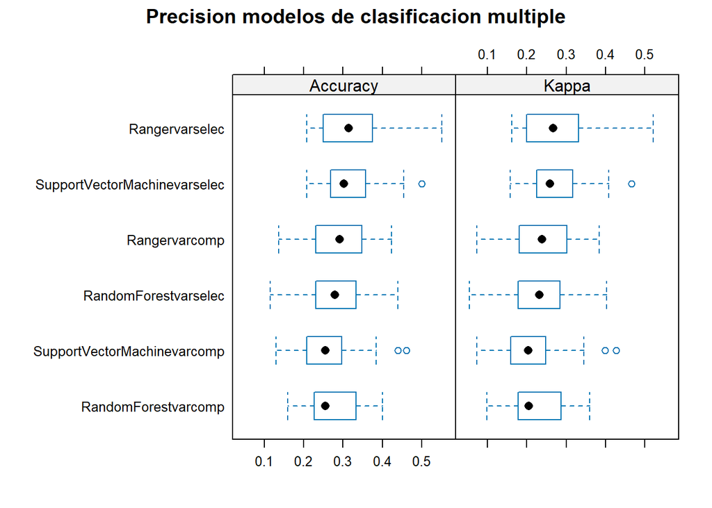

```r
bwplot(modelos.resamplep, main="Precision modelos de clasificacion multiple")
```

```r
difestp <- diff(modelos.resamplep, adjustment = "none")
summary(difestp)
```

```
##
## Call:
## summary.diff.resamples(object = difestp)
##
## Upper diagonal: estimates of the difference
## Lower diagonal: p-value for H0: difference = 0
##
## Accuracy
##                              Rangervarselec RandomForestvarselec
## Rangervarselec                               0.0311146
## RandomForestvarselec         0.148476
## SupportVectorMachinevarselec 0.962953       0.084755
## Rangervarcomp                0.192370       0.942209
## RandomForestvarcomp          0.045510       0.490772
## SupportVectorMachinevarcomp  0.003425       0.144480
##                              SupportVectorMachinevarselec Rangervarcomp
## Rangervarselec                0.0009913                    0.0297020
## RandomForestvarselec         -0.0301233                   -0.0014126
## SupportVectorMachinevarselec                               0.0287107
## Rangervarcomp                0.193579
## RandomForestvarcomp          0.025348                     0.455479
## SupportVectorMachinevarcomp  0.008751                     0.241026
##                              RandomForestvarcomp SupportVectorMachinevarcomp
## Rangervarselec                0.0442594           0.0564675
## RandomForestvarselec          0.0131449           0.0253530
## SupportVectorMachinevarselec  0.0432681           0.0554762
## Rangervarcomp                 0.0145574           0.0267655
## RandomForestvarcomp                               0.0122081
## SupportVectorMachinevarcomp  0.525181
##
## Kappa
##                              Rangervarselec RandomForestvarselec
## Rangervarselec                               0.0339666
## RandomForestvarselec         0.136211
## SupportVectorMachinevarselec 0.981743       0.069248
## Rangervarcomp                0.165403       0.983515
## RandomForestvarcomp          0.040471       0.480393
## SupportVectorMachinevarcomp  0.003985       0.171607
##                              SupportVectorMachinevarselec Rangervarcomp
## Rangervarselec                0.0005146                    0.0335405
## RandomForestvarselec         -0.0334520                   -0.0004261
## SupportVectorMachinevarselec                               0.0330259
## Rangervarcomp                0.159443
## RandomForestvarcomp          0.018666                     0.477540
## SupportVectorMachinevarcomp  0.008310                     0.292147
##                              RandomForestvarcomp SupportVectorMachinevarcomp
## Rangervarselec                0.0482813           0.0591084
## RandomForestvarselec          0.0143147           0.0251419
## SupportVectorMachinevarselec  0.0477667           0.0585938
## Rangervarcomp                 0.0147408           0.0255680
## RandomForestvarcomp                               0.0108271
## SupportVectorMachinevarcomp  0.594198
```

# 4. GENERACION DE MODELOS DE CLASIFICACIÓN BINARIA PARA PADRE

## 4.1 GENERACION DE MODELOS DE CLASIFICACION BINARIA PARA CLASE POSITIVA MARCONA.

### 4.1.1 MODELOS CON DATOS SELECCION DE VARIABLES.

Primero llevamos a cabo la seleccion de variables

```r
library(forcats)
datosp1sv <- datospr
datosp1sv$PADRE <- fct_other(datosp1sv$PADRE, keep = "Marcona", other_level = "OTROS")
table(datosp1sv$PADRE)
```

```
##
## Marcona   OTROS
##     133     786
```

```r
set.seed(12345)
datosp1svpart <- createDataPartition(datosp1sv$PADRE,p=0.8,list = FALSE)
datosp1sv.train <- datosp1sv[datosp1svpart,]
datosp1sv.test <- datosp1sv[-datosp1svpart,]
```

Balanceamos los datos

```r
datosp1sv.train_x = datosp1sv.train

maskneg = which(datosp1sv.train_x$PADRE == "OTROS") #Seleccionamos las clases distintas
maskpos = which(datosp1sv.train_x$PADRE == "Marcona") #Seleccinamos la clase
datosp1sv.train_x = datosp1sv.train_x[c(maskpos,sample(maskneg,length(maskpos))),]

datosp1sv.train_x = datosp1sv.train_x[sample(1:nrow(datosp1sv.train_x),nrow(datosp1sv.train_x)),]

datosp1sv.train_y = datosp1sv.train_x$PADRE

table(datosp1sv.train_x$PADRE)
```

```
##
## Marcona   OTROS
##     107     107
```

```r
subsets <- c(3:21) #Indicamos que cree subgrupos de entre 3 y 21 variables.

seeds <- vector(mode = "list", length = 6)

for(i in 1:10) seeds[[i]] <- sample.int(1000, length(subsets) + 1)
seeds[[11]] <- sample.int(1000, 1)

ctrl.treebag.rfe.cv.10padrebin <- rfeControl(functions=rfFuncs ,
                                     method = "cv",
                                     number = 10,
                                     seeds = seeds,
                                     returnResamp="final",
                                     verbose = TRUE,
                                     allowParallel = TRUE)
```

```r
treebag.rfe.cv.10padrebin <- rfe(PADRE~., data=datosp1sv.train_x,
                         sizes=subsets,
                         rfeControl=ctrl.treebag.rfe.cv.10padrebin)
```

Le quitamos el contenido de fit, para que no tenga tanto peso el archivo y guardammos el rds.

```r
treebag.rfe.cv.10padrebin$fit = NULL
saveRDS(treebag.rfe.cv.10padrebin, "C:/Users/gonza/Documents/TFM/treebag.fre.cv.10padrebin.rds")
```

```r
varselecpadrebin <- readRDS("C:/Users/gonza/Documents/TFM/treebag.fre.cv.10padrebin.rds")
varselecpadrebin$optVariables
```

```
##  [1] "GRAN1" "MADUR" "GRANO" "NOTA"  "PRINT" "CASC1" "CASCA" "ESPES" "FORMA"
## [10] "RENDI" "SABOR" "FLINT" "COLOR" "DUREZ" "DOBLE" "DOBLP" "FALLP" "FALLO"
## [19] "FRUTO" "RUGOS"
```

Las variables seleccionadas son : “GRAN1” “MADUR” “GRANO” “NOTA” “PRINT” “CASC1” “CASCA” “ESPES” “FORMA” “RENDI” “SABOR” “FLINT” “COLOR” “DUREZ” “DOBLE” “DOBLP” “FALLP” “FALLO” “FRUTO” “RUGOS”.

Ahora llevaremos a cabo los modelos con estas variables para comprobar la precision

Primero volveremos a seleccionar de los datos reducidos las variables de interes

```r
datosp1 <- datospr[, c("PADRE", "GRAN1" ,"MADUR", "GRANO" ,"NOTA"  ,"PRINT", "CASC1" ,"CASCA", "ESPES" ,"FORMA", "RENDI" ,"SABOR" ,"FLINT" ,"COLOR" ,"DUREZ", "DOBLE" ,"DOBLP" ,"FALLP" ,"FALLO" ,"FRUTO", "RUGOS")]
datosp1$PADRE <- fct_other(datosp1$PADRE, keep = "Marcona", other_level = "OTROS")
table(datosp1$PADRE)
```

```
##
## Marcona   OTROS
##     133     786
```

Balanceamos los datos.

```r
datosp1.id <- createDataPartition(datosp1$PADRE, p=0.7, list = FALSE)
datosp1.train <- datosp1[datosp1.id,]
datosp1.test <- datosp1[-datosp1.id,]
```

Ahora balancearemos los datos del train de cara a entrenar los modelos.

```r
datosp1.train_x = datosp1.train

maskneg = which(datosp1.train_x$PADRE == "OTROS") #Seleccionamos las clases distintas
maskpos = which(datosp1.train_x$PADRE == "Marcona") #Seleccinamos la clase
datosp1.train_x = datosp1.train_x[c(maskpos,sample(maskneg,length(maskpos))),]

datosp1.train_x = datosp1.train_x[sample(1:nrow(datosp1.train_x),nrow(datosp1.train_x)),]

datosp1.train_y = datosp1.train_x$PADRE

table(datosp1.train_x$PADRE)
```

```
##
## Marcona   OTROS
##      94      94
```

```r
datosp1.train_x$PADRE=NULL
```

Caret define por defecto la tecnica de remuestreo en la mitica bootstrap, sin embargo nosotros utilizaremos la crossvalidacion cruzada, en este caso de 10 pliegues con 3 repeticiones cada una (number=numero de pliegues -> 10 , repeats=numero de repeticiones -> 3). Además, añadimos la linea de comando verboseIter=TRUE para poder observar el avance del remuestreo en el entrenamiento del modelo.

```r
TrainCtrlRanger.3cv10 <- trainControl( # Crosvalidación de 10 pliegues con 3 repeticiones
  method = "repeatedcv",
  number = 10,
  repeats = 3,
  verboseIter=TRUE)
```

```r
modeloranger.3cv10.Marconasv <- train(x = datosp1.train_x,
                         y = datosp1.train_y,
                         method = "ranger",  #En este caso el metodo ranger
                         trControl = TrainCtrlRanger.3cv10)
```

```r
saveRDS(modeloranger.3cv10.Marconasv, "C:/Users/gonza/Documents/TFM/modelorangerMarconasvpadre.rds")
```

```r
modelorangerMarconasvpadre <- readRDS("C:/Users/gonza/Documents/TFM/modelorangerMarconasvpadre.rds")
modelorangerMarconasvpadre
```

```
## Random Forest
##
## 188 samples
##  20 predictor
##   2 classes: 'Marcona', 'OTROS'
##
## No pre-processing
## Resampling: Cross-Validated (10 fold, repeated 3 times)
## Summary of sample sizes: 169, 168, 169, 168, 169, 170, ...
## Resampling results across tuning parameters:
##
##   mtry  splitrule   Accuracy   Kappa
##    2    gini        0.8069493  0.6138753
##    2    extratrees  0.8181384  0.6363049
##   11    gini        0.8139766  0.6277985
##   11    extratrees  0.8123197  0.6245027
##   20    gini        0.8320273  0.6640497
##   20    extratrees  0.7982554  0.5967457
##
## Tuning parameter 'min.node.size' was held constant at a value of 1
## Accuracy was used to select the optimal model using the largest value.
## The final values used for the model were mtry = 20, splitrule = gini
##  and min.node.size = 1.
```

```r
rangerp1sv.prediction <- predict(modelorangerMarconasvpadre,datosp1.test)
rangerp1sv.confimatrix <- confusionMatrix(rangerp1sv.prediction, datosp1.test$PADRE)
rangerp1sv.confimatrix
```

Ahora el modelo rf

```r
TrainCtrlRf.3cv10 <- trainControl( # Crosvalidación de 10 pliegues con 3 repeticiones
  method = "repeatedcv",
  number = 10,
  repeats = 3,
  verboseIter=TRUE)
```

```r
modelorf.3cv10.Marconasv <- train(x = datosp1.train_x,
                         y = datosp1.train_y,
                         method = "rf",  #En este caso el metodo rf
                         trControl = TrainCtrlRf.3cv10)
```

```r
saveRDS(modelorf.3cv10.Marconasv, "C:/Users/gonza/Documents/TFM/modelorfMarconasvpadre.rds")
```

```r
modelorfMarconasvpadre <- readRDS("C:/Users/gonza/Documents/TFM/modelorfMarconasvpadre.rds")
modelorfMarconasvpadre
```

```
## Random Forest
##
## 188 samples
##  20 predictor
##   2 classes: 'Marcona', 'OTROS'
##
## No pre-processing
## Resampling: Cross-Validated (10 fold, repeated 3 times)
## Summary of sample sizes: 169, 170, 170, 169, 168, 168, ...
## Resampling results across tuning parameters:
##
##   mtry  Accuracy   Kappa
##    2    0.8232554  0.6455532
##   11    0.8023782  0.6035732
##   20    0.8249123  0.6492485
##
## Accuracy was used to select the optimal model using the largest value.
## The final value used for the model was mtry = 20.
```

```r
rfp1sv.prediction <- predict(modelorfMarconasvpadre,datosp1.test)
rfp1sv.confimatrix <- confusionMatrix(rfp1sv.prediction, datosp1.test$PADRE)
rfp1sv.confimatrix
```

Ahora el algoritmo SVM

```r
TrainCtrlsvm.3cv10 <- trainControl( # Crosvalidación de 10 pliegues con 3 repeticiones
  method = "repeatedcv",
  number = 10,
  repeats = 3,
  verboseIter=TRUE)
```

```r
modelosvm.3cv10.Marconasv <- train(x = datosp1.train_x,
                         y = datosp1.train_y,
                         method = "svmRadial",  #En este caso el metodo svm
                         trControl = TrainCtrlsvm.3cv10)
```

```r
saveRDS(modelosvm.3cv10.Marconasv, "C:/Users/gonza/Documents/TFM/modelosvmMarconasvpadre.rds")
```

```r
modelosvmMarconasvpadre <- readRDS("C:/Users/gonza/Documents/TFM/modelosvmMarconasvpadre.rds")
modelosvmMarconasvpadre
```

```
## Support Vector Machines with Radial Basis Function Kernel
##
## 188 samples
##  20 predictor
##   2 classes: 'Marcona', 'OTROS'
##
## No pre-processing
## Resampling: Cross-Validated (10 fold, repeated 3 times)
## Summary of sample sizes: 169, 169, 170, 168, 170, 170, ...
## Resampling results across tuning parameters:
##
##   C     Accuracy   Kappa
##   0.25  0.7632749  0.5247158
##   0.50  0.7876803  0.5743536
##   1.00  0.7842593  0.5675925
##
## Tuning parameter 'sigma' was held constant at a value of 0.04169193
## Accuracy was used to select the optimal model using the largest value.
## The final values used for the model were sigma = 0.04169193 and C = 0.5.
```

```r
svmp1sv.prediction <- predict(modelosvmMarconasvpadre,datosp1.test)
svmp1sv.confimatrix <- confusionMatrix(svmp1sv.prediction, datosp1.test$PADRE)
svmp1sv.confimatrix
```

### 4.1.2 MODELOS CON DATOS COMPLETOS

```r
datosp2 <- datospr
datosp2$PADRE <- fct_other(datosp2$PADRE, keep = "Marcona", other_level = "OTROS")
table(datosp2$PADRE)
```

```
##
## Marcona   OTROS
##     133     786
```

Balanceamos los datos.

```r
datosp2.id <- createDataPartition(datosp2$PADRE, p=0.7, list = FALSE)
datosp2.train <- datosp2[datosp2.id,]
datosp2.test <- datosp2[-datosp2.id,]
```

Ahora balancearemos los datos del train de cara a entrenar los modelos.

```r
datosp2.train_x = datosp2.train

maskneg = which(datosp2.train_x$PADRE == "OTROS") #Seleccionamos las clases distintas
maskpos = which(datosp2.train_x$PADRE == "Marcona") #Seleccinamos la clase
datosp2.train_x = datosp2.train_x[c(maskpos,sample(maskneg,length(maskpos))),]

datosp2.train_x = datosp2.train_x[sample(1:nrow(datosp2.train_x),nrow(datosp2.train_x)),]

datosp2.train_y = datosp2.train_x$PADRE

table(datosp2.train_x$PADRE)
```

```
##
## Marcona   OTROS
##      94      94
```

```r
datosp2.train_x$PADRE=NULL
```

Caret define por defecto la tecnica de remuestreo en la mitica bootstrap, sin embargo nosotros utilizaremos la crossvalidacion cruzada, en este caso de 10 pliegues con 3 repeticiones cada una (number=numero de pliegues -> 10 , repeats=numero de repeticiones -> 3). Además, añadimos la linea de comando verboseIter=TRUE para poder observar el avance del remuestreo en el entrenamiento del modelo.

```r
modeloranger.3cv10.MarconaC <- train(x = datosp2.train_x,
                         y = datosp2.train_y,
                         method = "ranger",  #En este caso el metodo ranger
                         trControl = TrainCtrlRanger.3cv10)
```

```r
saveRDS(modeloranger.3cv10.MarconaC, "C:/Users/gonza/Documents/TFM/modelorangerMarconaCpadre.rds")
```

```r
modelorangerMarconaCpadre <- readRDS("C:/Users/gonza/Documents/TFM/modelorangerMarconaCpadre.rds")
modelorangerMarconaCpadre
```

```
## Random Forest
##
## 188 samples
##  20 predictor
##   2 classes: 'Marcona', 'OTROS'
##
## No pre-processing
## Resampling: Cross-Validated (10 fold, repeated 3 times)
## Summary of sample sizes: 169, 170, 169, 169, 169, 169, ...
## Resampling results across tuning parameters:
##
##   mtry  splitrule   Accuracy   Kappa
##    2    gini        0.8278168  0.6565668
##    2    extratrees  0.8138402  0.6281207
##   11    gini        0.8166179  0.6342206
##   11    extratrees  0.8192105  0.6389749
##   20    gini        0.8133041  0.6273595
##   20    extratrees  0.8229045  0.6465380
##
## Tuning parameter 'min.node.size' was held constant at a value of 1
## Accuracy was used to select the optimal model using the largest value.
## The final values used for the model were mtry = 2, splitrule = gini
##  and min.node.size = 1.
```

```r
rangerp1C.prediction <- predict(modelorangerMarconaCpadre,datosp2.test)
rangerp1C.confimatrix <- confusionMatrix(rangerp1C.prediction, datosp2.test$PADRE)
rangerp1C.confimatrix
```

Ahora el modelo rf

```r
modelorf.3cv10.MarconaC <- train(x = datosp2.train_x,
                         y = datosp2.train_y,
                         method = "rf",  #En este caso el metodo rf
                         trControl = TrainCtrlRf.3cv10)
```

```r
saveRDS(modelorf.3cv10.MarconaC, "C:/Users/gonza/Documents/TFM/modelorfMarconaCpadre.rds")
```

```r
modelorfMarconaCpadre <- readRDS("C:/Users/gonza/Documents/TFM/modelorfMarconaCpadre.rds")
modelorfMarconaCpadre
```

```
## Random Forest
##
## 188 samples
##  20 predictor
##   2 classes: 'Marcona', 'OTROS'
##
## No pre-processing
## Resampling: Cross-Validated (10 fold, repeated 3 times)
## Summary of sample sizes: 169, 170, 169, 168, 170, 169, ...
## Resampling results across tuning parameters:
##
##   mtry  Accuracy   Kappa
##    2    0.8108869  0.6218840
##   11    0.8197758  0.6394632
##   20    0.8181189  0.6359692
##
## Accuracy was used to select the optimal model using the largest value.
## The final value used for the model was mtry = 11.
```

```r
caret::varImp(modelorfMarconaCpadre)
```

```
## rf variable importance
##
##       Overall
## GRAN1 100.000
## MADUR  59.252
## GRANO  58.886
## CASCA  28.329
## RENDI  25.041
## CASC1  21.899
## FORMA  21.479
## FLINT  13.693
## COLOR  13.212
## NOTA   11.887
## ESPES   9.804
## PRINT   9.442
## DOBLE   5.261
## RUGOS   5.247
## DOBLP   4.588
## FALLO   4.357
## FALLP   3.657
## DUREZ   3.159
## SABOR   1.714
## FRUTO   0.000
```

```r
rfp1C.prediction <- predict(modelorfMarconaCpadre,datosp2.test)
rfp1C.confimatrix <- confusionMatrix(rfp1C.prediction, datosp2.test$PADRE)
rfp1C.confimatrix
```

Ahora el algoritmo SVM

```r
modelosvm.3cv10.MarconaC <- train(x = datosp2.train_x,
                         y = datosp2.train_y,
                         method = "svmRadial",  #En este caso el metodo svm
                         trControl = TrainCtrlsvm.3cv10)
```

```r
saveRDS(modelosvm.3cv10.MarconaC, "C:/Users/gonza/Documents/TFM/modelosvmMarconaCpadre.rds")
```

```r
modelosvmMarconaCpadre <- readRDS("C:/Users/gonza/Documents/TFM/modelosvmMarconaCpadre.rds")
modelosvmMarconaCpadre
```

```
## Support Vector Machines with Radial Basis Function Kernel
##
## 188 samples
##  20 predictor
##   2 classes: 'Marcona', 'OTROS'
##
## No pre-processing
## Resampling: Cross-Validated (10 fold, repeated 3 times)
## Summary of sample sizes: 170, 169, 169, 168, 170, 170, ...
## Resampling results across tuning parameters:
##
##   C     Accuracy   Kappa
##   0.25  0.7980019  0.5954656
##   0.50  0.8124366  0.6247099
##   1.00  0.8175049  0.6348005
##
## Tuning parameter 'sigma' was held constant at a value of 0.03970972
## Accuracy was used to select the optimal model using the largest value.
## The final values used for the model were sigma = 0.03970972 and C = 1.
```

```r
svmp1C.prediction <- predict(modelosvmMarconaCpadre,datosp2.test)
svmp1C.confimatrix <- confusionMatrix(svmp1C.prediction, datosp2.test$PADRE)
svmp1C.confimatrix
```

### 4.1.3 COMPARACION DE MODELOS DE CLASIFICACION BINARIA

```r
listamodelospadresMarcona <- list(Rangervarselec=modelorangerMarconasvpadre,RandomForestvarselec=modelorfMarconasvpadre,SupportVectorMachinevarselec=modelosvmMarconasvpadre,Rangervarcomp=modelorangerMarconaCpadre, RandomForestvarcomp=modelorfMarconaCpadre, SupportVectorMachinevarcomp=modelosvmMarconaCpadre)
modelos.resampleMarcona <- resamples(listamodelospadresMarcona)
summary(modelos.resampleMarcona)
```

```
##
## Call:
## summary.resamples(object = modelos.resampleMarcona)
##
## Models: Rangervarselec, RandomForestvarselec, SupportVectorMachinevarselec, Rangervarcomp, RandomForestvarcomp, SupportVectorMachinevarcomp
## Number of resamples: 30
##
## Accuracy
##                                   Min.   1st Qu.    Median      Mean   3rd Qu.
## Rangervarselec               0.7368421 0.7921053 0.8333333 0.8320273 0.8791667
## RandomForestvarselec         0.6842105 0.7807018 0.8333333 0.8249123 0.8888889
## SupportVectorMachinevarselec 0.6000000 0.7569444 0.7894737 0.7876803 0.8333333
## Rangervarcomp                0.6315789 0.7777778 0.8421053 0.8278168 0.8947368
## RandomForestvarcomp          0.6500000 0.7807018 0.8421053 0.8197758 0.8888889
## SupportVectorMachinevarcomp  0.6315789 0.7500000 0.8166667 0.8175049 0.8888889
##                                   Max. NA's
## Rangervarselec               0.9500000    0
## RandomForestvarselec         0.9473684    0
## SupportVectorMachinevarselec 0.9444444    0
## Rangervarcomp                0.9473684    0
## RandomForestvarcomp          0.9500000    0
## SupportVectorMachinevarcomp  1.0000000    0
##
## Kappa
##                                   Min.   1st Qu.    Median      Mean   3rd Qu.
## Rangervarselec               0.4751381 0.5797753 0.6666667 0.6640497 0.7583333
## RandomForestvarselec         0.3736264 0.5611111 0.6666667 0.6492485 0.7777778
## SupportVectorMachinevarselec 0.2000000 0.5138889 0.5777778 0.5743536 0.6666667
## Rangervarcomp                0.2651934 0.5555556 0.6833236 0.6565668 0.7888889
## RandomForestvarcomp          0.3000000 0.5599251 0.6815642 0.6394632 0.7777778
## SupportVectorMachinevarcomp  0.2569832 0.5000000 0.6333333 0.6348005 0.7777778
##                                   Max. NA's
## Rangervarselec               0.9000000    0
## RandomForestvarselec         0.8938547    0
## SupportVectorMachinevarselec 0.8888889    0
## Rangervarcomp                0.8950276    0
## RandomForestvarcomp          0.9000000    0
## SupportVectorMachinevarcomp  1.0000000    0
```

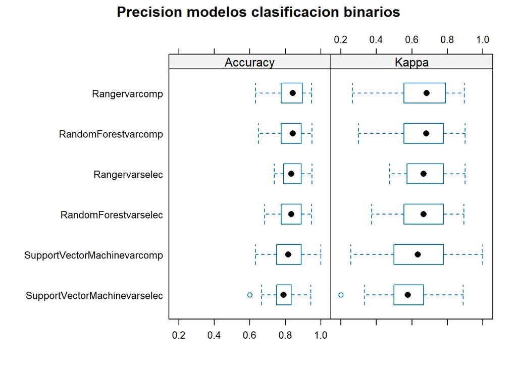

```r
bwplot(modelos.resampleMarcona, main="Precision modelos clasificacion binarios")
```

```r
difestMarcona <- diff(modelos.resampleMarcona, adjustment = "none")
summary(difestMarcona)
```

```
##
## Call:
## summary.diff.resamples(object = difestMarcona)
##
## Upper diagonal: estimates of the difference
## Lower diagonal: p-value for H0: difference = 0
##
## Accuracy
##                              Rangervarselec RandomForestvarselec
## Rangervarselec                               0.007115
## RandomForestvarselec         0.673922
## SupportVectorMachinevarselec 0.002876       0.029743
## Rangervarcomp                0.833175       0.887238
## RandomForestvarcomp          0.502782       0.806508
## SupportVectorMachinevarcomp  0.466408       0.734736
##                              SupportVectorMachinevarselec Rangervarcomp
## Rangervarselec                0.044347                     0.004211
## RandomForestvarselec          0.037232                    -0.002904
## SupportVectorMachinevarselec                              -0.040136
## Rangervarcomp                0.024244
## RandomForestvarcomp          0.170068                     0.765663
## SupportVectorMachinevarcomp  0.146306                     0.669330
##                              RandomForestvarcomp SupportVectorMachinevarcomp
## Rangervarselec                0.012251            0.014522
## RandomForestvarselec          0.005136            0.007407
## SupportVectorMachinevarselec -0.032096           -0.029825
## Rangervarcomp                 0.008041            0.010312
## RandomForestvarcomp                               0.002271
## SupportVectorMachinevarcomp  0.913973
##
## Kappa
##                              Rangervarselec RandomForestvarselec
## Rangervarselec                               0.014801
## RandomForestvarselec         0.661676
## SupportVectorMachinevarselec 0.002797       0.029030
## Rangervarcomp                0.850951       0.857721
## RandomForestvarcomp          0.500428       0.815623
## SupportVectorMachinevarcomp  0.463357       0.741265
##                              SupportVectorMachinevarselec Rangervarcomp
## Rangervarselec                0.089696                     0.007483
## RandomForestvarselec          0.074895                    -0.007318
## SupportVectorMachinevarselec                              -0.082213
## Rangervarcomp                0.022150
## RandomForestvarcomp          0.164470                     0.750147
## SupportVectorMachinevarcomp  0.142061                     0.651860
##                              RandomForestvarcomp SupportVectorMachinevarcomp
## Rangervarselec                0.024587            0.029249
## RandomForestvarselec          0.009785            0.014448
## SupportVectorMachinevarselec -0.065110           -0.060447
## Rangervarcomp                 0.017104            0.021766
## RandomForestvarcomp                               0.004663
## SupportVectorMachinevarcomp  0.911582
```

### 4.1.4 SELECCIÓN DEL MEJOR CRUZAMIENTO

```r
# Muestra optima de almendra
muestra <- data.frame(FLINT = 5, PRINT = 5, MADUR = 200, FRUTO = 25, CASCA = 80, CASC1 = 2, DUREZ = 3, GRANO = 30, GRAN1 = 1,2 , RENDI = 100, FALLO = 0, FALLP = 0, DOBLE = 0, DOBLP = 0, FORMA = 4, ESPES = 3, RUGOS = 2, COLOR = 3, SABOR = 3, NOTA = 5)  # Agrega las variables correspondientes a tu muestra

# Predicción del grupo de la muestra inventada
prediccionoptimap <- predict(modelorangerMarconaCpadre, newdata = muestra)

# Resultado de la predicción
print(prediccionoptimap)
```

```
## [1] Marcona
## Levels: Marcona OTROS
```

Nuestro padre podria ser marcona

```r
# Muestra distinta
muestrados <- data.frame(FLINT = 3, PRINT = 3, MADUR = 220, FRUTO = 25, CASCA = 80, CASC1 = 2, DUREZ = 3, GRANO = 30, GRAN1 = 1,2 , RENDI = 80, FALLO = 0, FALLP = 0, DOBLE = 0, DOBLP = 0, FORMA = 4, ESPES = 3, RUGOS = 2, COLOR = 4, SABOR = 3, NOTA = 4)

# Predicción del grupo de la muestra optima
prediccionoptimados <- predict(modelorangerMarconaCpadre, newdata = muestrados)

# Resultado de la predicción
print(prediccionoptimados)
```

```
## [1] Marcona
## Levels: Marcona OTROS
```

A partir de ahora se llevara a cabo un enfoque de clasificacion binario sin seleccion de variables, utilizando el algoritmo ranger y se usara rf para ver la importancia de las variables.

## 4.2 GENERACION DE MODELOS DE CLASIFICACION BINARIA PARA CLASE POSITIVA R1000.

```r
datosp2 <- datospr
datosp2$PADRE <- fct_other(datosp2$PADRE, keep = "R1000", other_level = "OTROS")
table(datosp2$PADRE)
```

```
##
## R1000 OTROS
##   101   818
```

Balanceamos los datos.

```r
datosp2.id <- createDataPartition(datosp2$PADRE, p=0.7, list = FALSE)
datosp2.train <- datosp2[datosp2.id,]
datosp2.test <- datosp2[-datosp2.id,]
```

Ahora balancearemos los datos del train de cara a entrenar los modelos.

```r
datosp2.train_x = datosp2.train

maskneg = which(datosp2.train_x$PADRE == "OTROS") #Seleccionamos las clases distintas
maskpos = which(datosp2.train_x$PADRE == "R1000") #Seleccinamos la clase
datosp2.train_x = datosp2.train_x[c(maskpos,sample(maskneg,length(maskpos))),]

datosp2.train_x = datosp2.train_x[sample(1:nrow(datosp2.train_x),nrow(datosp2.train_x)),]

datosp2.train_y = datosp2.train_x$PADRE

table(datosp2.train_x$PADRE)
```

```
##
## R1000 OTROS
##    71    71
```

```r
datosp2.train_x$PADRE=NULL
```

Caret define por defecto la tecnica de remuestreo en la mitica bootstrap, sin embargo nosotros utilizaremos la crossvalidacion cruzada, en este caso de 10 pliegues con 3 repeticiones cada una (number=numero de pliegues -> 10 , repeats=numero de repeticiones -> 3). Además, añadimos la linea de comando verboseIter=TRUE para poder observar el avance del remuestreo en el entrenamiento del modelo.

```r
modeloranger.3cv10.R1000 <- train(x = datosp2.train_x,
                         y = datosp2.train_y,
                         method = "ranger",  #En este caso el metodo ranger
                         trControl = TrainCtrlRanger.3cv10)
```

```r
saveRDS(modeloranger.3cv10.R1000, "C:/Users/gonza/Documents/TFM/modelorangerR1000p.rds")
```

```r
modelorangerR1000p <- readRDS("C:/Users/gonza/Documents/TFM/modelorangerR1000p.rds")
modelorangerR1000p
```

```
## Random Forest
##
## 142 samples
##  20 predictor
##   2 classes: 'R1000', 'OTROS'
##
## No pre-processing
## Resampling: Cross-Validated (10 fold, repeated 3 times)
## Summary of sample sizes: 128, 127, 128, 128, 128, 128, ...
## Resampling results across tuning parameters:
##
##   mtry  splitrule   Accuracy   Kappa
##    2    gini        0.6688889  0.3381797
##    2    extratrees  0.7273016  0.4543015
##   11    gini        0.6574603  0.3154543
##   11    extratrees  0.6757143  0.3513716
##   20    gini        0.6595238  0.3195455
##   20    extratrees  0.6615873  0.3232252
##
## Tuning parameter 'min.node.size' was held constant at a value of 1
## Accuracy was used to select the optimal model using the largest value.
## The final values used for the model were mtry = 2, splitrule = extratrees
##  and min.node.size = 1.
```

```r
ranger.predictionp2 <- predict(modelorangerR1000p,datosp2.test)
ranger.confimatrixp2 <- confusionMatrix(ranger.predictionp2, datosp2.test$PADRE)
ranger.confimatrixp2
```

Ahora algorimto rf para la importancia

```r
modelorf.3cv10.R1000 <- train(x = datosp2.train_x,
                         y = datosp2.train_y,
                         method = "rf",  #En este caso el metodo ranger
                         trControl = TrainCtrlRf.3cv10)
```

```r
saveRDS(modelorf.3cv10.R1000, "C:/Users/gonza/Documents/TFM/modelorfR1000p.rds")
```

```r
modelorfR1000p <- readRDS("C:/Users/gonza/Documents/TFM/modelorfR1000p.rds")
modelorfR1000p
```

```
## Random Forest
##
## 142 samples
##  20 predictor
##   2 classes: 'R1000', 'OTROS'
##
## No pre-processing
## Resampling: Cross-Validated (10 fold, repeated 3 times)
## Summary of sample sizes: 128, 128, 128, 127, 128, 128, ...
## Resampling results across tuning parameters:
##
##   mtry  Accuracy   Kappa
##    2    0.6880952  0.3754754
##   11    0.6573016  0.3143955
##   20    0.6620635  0.3240643
##
## Accuracy was used to select the optimal model using the largest value.
## The final value used for the model was mtry = 2.
```

```r
caret::varImp(modelorfR1000p)
```

```
## rf variable importance
##
##       Overall
## GRAN1 100.000
## GRANO  96.299
## RENDI  79.018
## CASCA  69.343
## MADUR  64.832
## CASC1  64.411
## FORMA  36.760
## COLOR  32.859
## FALLP  32.581
## DOBLE  29.674
## FALLO  27.022
## DOBLP  26.618
## FLINT  26.554
## PRINT  26.318
## ESPES  23.362
## RUGOS  22.868
## DUREZ  20.794
## NOTA   19.609
## SABOR   8.012
## FRUTO   0.000
```

```r
rf.predictionp2 <- predict(modelorfR1000p,datosp2.test)
rf.confimatrixp2 <- confusionMatrix(rf.predictionp2, datosp2.test$PADRE)
rf.confimatrixp2
```

### 4.2.1 SELECCIÓN DEL MEJOR CRUZAMIENTO

```r
# Predicción del grupo de la muestra inventada
prediccionoptimap2 <- predict(modelorangerR1000p, newdata = muestra)

# Resultado de la predicción
print(prediccionoptimap2)
```

```
## [1] OTROS
## Levels: R1000 OTROS
```

Perteneceria a otro padre nuestra planta optima.

```r
# Predicción del grupo de la muestra inventada
prediccionoptimapdos2 <- predict(modelorangerR1000p, newdata = muestrados)

# Resultado de la predicción
print(prediccionoptimapdos2)
```

```
## [1] OTROS
## Levels: R1000 OTROS
```

## 4.3 GENERACION DE MODELOS DE CLASIFICACION BINARIA PARA CLASE POSITIVA A2198

```r
datosp3 <- datospr
datosp3$PADRE <- fct_other(datosp3$PADRE, keep = "A2198", other_level = "OTROS")
table(datosp3$PADRE)
```

```
##
## A2198 OTROS
##    96   823
```

Balanceamos los datos.

```r
datosp3.id <- createDataPartition(datosp3$PADRE, p=0.7, list = FALSE)
datosp3.train <- datosp3[datosp3.id,]
datosp3.test <- datosp3[-datosp3.id,]
```

Ahora balancearemos los datos del train de cara a entrenar los modelos.

```r
datosp3.train_x = datosp3.train

maskneg = which(datosp3.train_x$PADRE == "OTROS") #Seleccionamos las clases distintas
maskpos = which(datosp3.train_x$PADRE == "A2198") #Seleccinamos la clase
datosp3.train_x = datosp3.train_x[c(maskpos,sample(maskneg,length(maskpos))),]

datosp3.train_x = datosp3.train_x[sample(1:nrow(datosp3.train_x),nrow(datosp3.train_x)),]

datosp3.train_y = datosp3.train_x$PADRE

table(datosp3.train_x$PADRE)
```

```
##
## A2198 OTROS
##    68    68
```

```r
datosp3.train_x$PADRE=NULL
```

Caret define por defecto la tecnica de remuestreo en la mitica bootstrap, sin embargo nosotros utilizaremos la crossvalidacion cruzada, en este caso de 10 pliegues con 3 repeticiones cada una (number=numero de pliegues -> 10 , repeats=numero de repeticiones -> 3). Además, añadimos la linea de comando verboseIter=TRUE para poder observar el avance del remuestreo en el entrenamiento del modelo.

```r
modeloranger.3cv10.A2198 <- train(x = datosp3.train_x,
                         y = datosp3.train_y,
                         method = "ranger",  #En este caso el metodo ranger
                         trControl = TrainCtrlRanger.3cv10)
```

```r
saveRDS(modeloranger.3cv10.A2198, "C:/Users/gonza/Documents/TFM/modelorangerA2198p.rds")
```

```r
modelorangerA2198p <- readRDS("C:/Users/gonza/Documents/TFM/modelorangerA2198p.rds")
modelorangerA2198p
```

```
## Random Forest
##
## 136 samples
##  20 predictor
##   2 classes: 'A2198', 'OTROS'
##
## No pre-processing
## Resampling: Cross-Validated (10 fold, repeated 3 times)
## Summary of sample sizes: 122, 124, 122, 122, 122, 122, ...
## Resampling results across tuning parameters:
##
##   mtry  splitrule   Accuracy   Kappa
##    2    gini        0.7565324  0.5132466
##    2    extratrees  0.7668193  0.5340101
##   11    gini        0.7466422  0.4944465
##   11    extratrees  0.7711844  0.5419850
##   20    gini        0.7415140  0.4843806
##   20    extratrees  0.7634921  0.5268232
##
## Tuning parameter 'min.node.size' was held constant at a value of 1
## Accuracy was used to select the optimal model using the largest value.
## The final values used for the model were mtry = 11, splitrule = extratrees
##  and min.node.size = 1.
```

```r
ranger.predictionp3 <- predict(modelorangerA2198p,datosp3.test)
ranger.confimatrixp3 <- confusionMatrix(ranger.predictionp3, datosp3.test$PADRE)
ranger.confimatrixp3
```

Ahora algorimto rf para la importancia

```r
modelorf.3cv10.A2198 <- train(x = datosp3.train_x,
                         y = datosp3.train_y,
                         method = "rf",  #En este caso el metodo rf
                         trControl = TrainCtrlRf.3cv10)
```

```r
saveRDS(modelorf.3cv10.A2198, "C:/Users/gonza/Documents/TFM/modelorfA2198p.rds")
```

```r
modelorfA2198p <- readRDS("C:/Users/gonza/Documents/TFM/modelorfA2198p.rds")
modelorfA2198p
```

```
## Random Forest
##
## 136 samples
##  20 predictor
##   2 classes: 'A2198', 'OTROS'
##
## No pre-processing
## Resampling: Cross-Validated (10 fold, repeated 3 times)
## Summary of sample sizes: 122, 122, 123, 123, 122, 123, ...
## Resampling results across tuning parameters:
##
##   mtry  Accuracy   Kappa
##    2    0.7664835  0.5309304
##   11    0.7635531  0.5250462
##   20    0.7540293  0.5062457
##
## Accuracy was used to select the optimal model using the largest value.
## The final value used for the model was mtry = 2.
```

```r
caret::varImp(modelorfA2198p)
```

```
## rf variable importance
##
##       Overall
## RENDI  100.00
## MADUR   84.14
## GRANO   57.31
## CASCA   53.55
## CASC1   52.34
## GRAN1   52.23
## FORMA   42.92
## ESPES   42.59
## NOTA    37.61
## PRINT   27.16
## FLINT   24.38
## COLOR   22.61
## DOBLE   22.29
## DOBLP   20.89
## DUREZ   20.63
## RUGOS   20.56
## FALLP   14.07
## FALLO   13.09
## SABOR   11.96
## FRUTO    0.00
```

```r
rf.predictionp3 <- predict(modelorfA2198p,datosp3.test)
rf.confimatrixp3 <- confusionMatrix(rf.predictionp3, datosp3.test$PADRE)
rf.confimatrixp3
```

### 4.3.1 SELECCIÓN DEL MEJOR CRUZAMIENTO

```r
# Predicción del grupo de la muestra inventada
prediccionoptimap3 <- predict(modelorangerA2198p, newdata = muestra)

# Resultado de la predicción
print(prediccionoptimap3)
```

```
## [1] A2198
## Levels: A2198 OTROS
```

Perteneceria a este padre nuestra planta optima.

```r
# Predicción del grupo de la muestra inventada
prediccionoptimapdos3 <- predict(modelorangerA2198p, newdata = muestrados)

# Resultado de la predicción
print(prediccionoptimapdos3)
```

```
## [1] A2198
## Levels: A2198 OTROS
```

## 4.4 GENERACION DE MODELOS DE CLASIFICACION BINARIA PARA CLASE POSITIVA Antoneta

```r
datosp4 <- datospr
datosp4$PADRE <- fct_other(datosp4$PADRE, keep = "Antoneta", other_level = "OTROS")
table(datosp4$PADRE)
```

```
##
## Antoneta    OTROS
##       93      826
```

Balanceamos los datos.

```r
datosp4.id <- createDataPartition(datosp4$PADRE, p=0.7, list = FALSE)
datosp4.train <- datosp4[datosp4.id,]
datosp4.test <- datosp4[-datosp4.id,]
```

Ahora balancearemos los datos del train de cara a entrenar los modelos.

```r
datosp4.train_x = datosp4.train

maskneg = which(datosp4.train_x$PADRE == "OTROS") #Seleccionamos las clases distintas
maskpos = which(datosp4.train_x$PADRE == "Antoneta") #Seleccinamos la clase
datosp4.train_x = datosp4.train_x[c(maskpos,sample(maskneg,length(maskpos))),]

datosp4.train_x = datosp4.train_x[sample(1:nrow(datosp4.train_x),nrow(datosp4.train_x)),]

datosp4.train_y = datosp4.train_x$PADRE

table(datosp4.train_x$PADRE)
```

```
##
## Antoneta    OTROS
##       66       66
```

```r
datosp4.train_x$PADRE=NULL
```

Caret define por defecto la tecnica de remuestreo en la mitica bootstrap, sin embargo nosotros utilizaremos la crossvalidacion cruzada, en este caso de 10 pliegues con 3 repeticiones cada una (number=numero de pliegues -> 10 , repeats=numero de repeticiones -> 3). Además, añadimos la linea de comando verboseIter=TRUE para poder observar el avance del remuestreo en el entrenamiento del modelo.

```r
modeloranger.3cv10.Antoneta <- train(x = datosp4.train_x,
                         y = datosp4.train_y,
                         method = "ranger",  #En este caso el metodo ranger
                         trControl = TrainCtrlRanger.3cv10)
```

```r
saveRDS(modeloranger.3cv10.Antoneta, "C:/Users/gonza/Documents/TFM/modelorangerAntonetap.rds")
```

```r
modelorangerAntonetap <- readRDS("C:/Users/gonza/Documents/TFM/modelorangerAntonetap.rds")
modelorangerAntonetap
```

```
## Random Forest
##
## 132 samples
##  20 predictor
##   2 classes: 'Antoneta', 'OTROS'
##
## No pre-processing
## Resampling: Cross-Validated (10 fold, repeated 3 times)
## Summary of sample sizes: 118, 118, 119, 118, 120, 119, ...
## Resampling results across tuning parameters:
##
##   mtry  splitrule   Accuracy   Kappa
##    2    gini        0.7766484  0.5523522
##    2    extratrees  0.7657204  0.5326221
##   11    gini        0.7869353  0.5729506
##   11    extratrees  0.8203297  0.6408170
##   20    gini        0.7901099  0.5799014
##   20    extratrees  0.8152015  0.6301245
##
## Tuning parameter 'min.node.size' was held constant at a value of 1
## Accuracy was used to select the optimal model using the largest value.
## The final values used for the model were mtry = 11, splitrule = extratrees
##  and min.node.size = 1.
```

```r
ranger.predictionp4 <- predict(modelorangerAntonetap,datosp4.test)
ranger.confimatrixp4 <- confusionMatrix(ranger.predictionp4, datosp4.test$PADRE)
ranger.confimatrixp4
```

Ahora algorimto rf para la importancia

```r
modelorf.3cv10.Antoneta <- train(x = datosp4.train_x,
                         y = datosp4.train_y,
                         method = "rf",  #En este caso el metodo rf
                         trControl = TrainCtrlRf.3cv10)
```

```r
saveRDS(modelorf.3cv10.Antoneta, "C:/Users/gonza/Documents/TFM/modelorfAntonetap.rds")
```

```r
modelorfAntonetap <- readRDS("C:/Users/gonza/Documents/TFM/modelorfAntonetap.rds")
modelorfAntonetap
```

```
## Random Forest
##
## 132 samples
##  20 predictor
##   2 classes: 'Antoneta', 'OTROS'
##
## No pre-processing
## Resampling: Cross-Validated (10 fold, repeated 3 times)
## Summary of sample sizes: 120, 118, 119, 120, 119, 118, ...
## Resampling results across tuning parameters:
##
##   mtry  Accuracy   Kappa
##    2    0.7876068  0.5753280
##   11    0.7915140  0.5826663
##   20    0.7938950  0.5876609
##
## Accuracy was used to select the optimal model using the largest value.
## The final value used for the model was mtry = 20.
```

```r
caret::varImp(modelorfAntonetap)
```

```
## rf variable importance
##
##       Overall
## MADUR 100.000
## RUGOS  22.326
## GRANO  18.232
## FORMA  17.403
## RENDI  17.350
## CASCA  16.522
## CASC1  14.813
## FLINT  14.203
## GRAN1  11.750
## PRINT   4.990
## ESPES   4.945
## DOBLP   4.250
## DOBLE   4.161
## NOTA    3.257
## COLOR   3.174
## FALLO   1.966
## DUREZ   1.497
## FALLP   1.408
## FRUTO   1.231
## SABOR   0.000
```

```r
rf.predictionp4 <- predict(modelorfAntonetap,datosp4.test)
rf.confimatrixp4 <- confusionMatrix(rf.predictionp4, datosp4.test$PADRE)
rf.confimatrixp4
```

### 4.4.1 SELECCIÓN DEL MEJOR CRUZAMIENTO

```r
# Predicción del grupo de la muestra inventada
prediccionoptimap4 <- predict(modelorangerAntonetap, newdata = muestra)

# Resultado de la predicción
print(prediccionoptimap4)
```

```
## [1] Antoneta
## Levels: Antoneta OTROS
```

Podria pertencer a Antoñeta nuestro padre optimo

```r
# Predicción del grupo de la muestra inventada
prediccionoptimapdos4 <- predict(modelorangerAntonetap, newdata = muestrados)

# Resultado de la predicción
print(prediccionoptimapdos4)
```

```
## [1] OTROS
## Levels: Antoneta OTROS
```

## 4.5 GENERACION DE MODELOS DE CLASIFICACION BINARIA PARA CLASE POSITIVA Marta

```r
datosp5 <- datospr
datosp5$PADRE <- fct_other(datosp5$PADRE, keep = "Marta", other_level = "OTROS")
table(datosp5$PADRE)
```

```
##
## Marta OTROS
##    88   831
```

Balanceamos los datos.

```r
datosp5.id <- createDataPartition(datosp5$PADRE, p=0.7, list = FALSE)
datosp5.train <- datosp5[datosp5.id,]
datosp5.test <- datosp5[-datosp5.id,]
```

Ahora balancearemos los datos del train de cara a entrenar los modelos.

```r
datosp5.train_x = datosp5.train

maskneg = which(datosp5.train_x$PADRE == "OTROS") #Seleccionamos las clases distinta
maskpos = which(datosp5.train_x$PADRE == "Marta") #Seleccinamos la clase
datosp5.train_x = datosp5.train_x[c(maskpos,sample(maskneg,length(maskpos))),]

datosp5.train_x = datosp5.train_x[sample(1:nrow(datosp5.train_x),nrow(datosp5.train_x)),]

datosp5.train_y = datosp5.train_x$PADRE

table(datosp5.train_x$PADRE)
```

```
##
## Marta OTROS
##    62    62
```

```r
datosp5.train_x$PADRE=NULL
```

Caret define por defecto la tecnica de remuestreo en la mitica bootstrap, sin embargo nosotros utilizaremos la crossvalidacion cruzada, en este caso de 10 pliegues con 3 repeticiones cada una (number=numero de pliegues -> 10 , repeats=numero de repeticiones -> 3). Además, añadimos la linea de comando verboseIter=TRUE para poder observar el avance del remuestreo en el entrenamiento del modelo.

```r
modeloranger.3cv10.Marta <- train(x = datosp5.train_x,
                         y = datosp5.train_y,
                         method = "ranger",  #En este caso el metodo ranger
                         trControl = TrainCtrlRanger.3cv10)
```

```r
saveRDS(modeloranger.3cv10.Marta, "C:/Users/gonza/Documents/TFM/modelorangerMartap.rds")
```

```r
modelorangerMartap <- readRDS("C:/Users/gonza/Documents/TFM/modelorangerMartap.rds")
modelorangerMartap
```

```
## Random Forest
##
## 124 samples
##  20 predictor
##   2 classes: 'Marta', 'OTROS'
##
## No pre-processing
## Resampling: Cross-Validated (10 fold, repeated 3 times)
## Summary of sample sizes: 112, 112, 112, 111, 111, 112, ...
## Resampling results across tuning parameters:
##
##   mtry  splitrule   Accuracy   Kappa
##    2    gini        0.7006716  0.4015051
##    2    extratrees  0.6793040  0.3599362
##   11    gini        0.6844322  0.3686746
##   11    extratrees  0.6961844  0.3944600
##   20    gini        0.6543040  0.3079926
##   20    extratrees  0.6957570  0.3924590
##
## Tuning parameter 'min.node.size' was held constant at a value of 1
## Accuracy was used to select the optimal model using the largest value.
## The final values used for the model were mtry = 2, splitrule = gini
##  and min.node.size = 1.
```

```r
ranger.predictionp5 <- predict(modelorangerMartap,datosp5.test)
ranger.confimatrixp5 <- confusionMatrix(ranger.predictionp5, datosp5.test$PADRE)
ranger.confimatrixp5
```

Ahora algorimto rf para la importancia

```r
modelorf.3cv10.Marta <- train(x = datosp5.train_x,
                         y = datosp5.train_y,
                         method = "rf",  #En este caso el metodo rf
                         trControl = TrainCtrlRf.3cv10)
```

```r
saveRDS(modelorf.3cv10.Marta, "C:/Users/gonza/Documents/TFM/modelorfMartap.rds")
```

```r
modelorfMartap <- readRDS("C:/Users/gonza/Documents/TFM/modelorfMartap.rds")
modelorfMartap
```

```
## Random Forest
##
## 124 samples
##  20 predictor
##   2 classes: 'Marta', 'OTROS'
##
## No pre-processing
## Resampling: Cross-Validated (10 fold, repeated 3 times)
## Summary of sample sizes: 112, 111, 112, 111, 112, 112, ...
## Resampling results across tuning parameters:
##
##   mtry  Accuracy   Kappa
##    2    0.6836081  0.3633978
##   11    0.6942918  0.3850882
##   20    0.6748168  0.3465947
##
## Accuracy was used to select the optimal model using the largest value.
## The final value used for the model was mtry = 11.
```

```r
caret::varImp(modelorfMartap)
```

```
## rf variable importance
##
##       Overall
## MADUR 100.000
## RENDI  45.045
## GRANO  44.689
## GRAN1  42.123
## CASCA  32.250
## CASC1  29.494
## FORMA  23.386
## PRINT  17.688
## ESPES  15.343
## COLOR  14.928
## NOTA   11.386
## FALLP  10.640
## FLINT   8.914
## SABOR   8.704
## DOBLP   8.379
## FALLO   7.703
## DOBLE   7.635
## DUREZ   7.594
## RUGOS   6.155
## FRUTO   0.000
```

```r
rf.predictionp5 <- predict(modelorfMartap,datosp5.test)
rf.confimatrixp5 <- confusionMatrix(rf.predictionp5, datosp5.test$PADRE)
rf.confimatrixp5
```

### 4.5.1 SELECCIÓN DEL MEJOR CRUZAMIENTO

```r
# Predicción del grupo de la muestra inventada
prediccionoptimap5 <- predict(modelorangerMartap, newdata = muestra)

# Resultado de la predicción
print(prediccionoptimap5)
```

```
## [1] Marta
## Levels: Marta OTROS
```

Podria pertencer a Marta nuestro padre optimo

```r
# Predicción del grupo de la muestra inventada
prediccionoptimapdos5 <- predict(modelorangerMartap, newdata = muestrados)

# Resultado de la predicción
print(prediccionoptimapdos5)
```

```
## [1] Marta
## Levels: Marta OTROS
```

## 4.6 GENERACION DE MODELOS DE CLASIFICACION BINARIA PARA CLASE POSITIVA D01i466

```r
datosp6 <- datospr
datosp6$PADRE <- fct_other(datosp6$PADRE, keep = "D01i466", other_level = "OTROS")
table(datosp6$PADRE)
```

```
##
## D01i466   OTROS
##      63     856
```

Balanceamos los datos.

```r
datosp6.id <- createDataPartition(datosp6$PADRE, p=0.7, list = FALSE)
datosp6.train <- datosp6[datosp6.id,]
datosp6.test <- datosp6[-datosp6.id,]
```

Ahora balancearemos los datos del train de cara a entrenar los modelos.

```r
datosp6.train_x = datosp6.train

maskneg = which(datosp6.train_x$PADRE == "OTROS") #Seleccionamos las clases distintas
maskpos = which(datosp6.train_x$PADRE == "D01i466") #Seleccinamos la clase
datosp6.train_x = datosp6.train_x[c(maskpos,sample(maskneg,length(maskpos))),]

datosp6.train_x = datosp6.train_x[sample(1:nrow(datosp6.train_x),nrow(datosp6.train_x)),]

datosp6.train_y = datosp6.train_x$PADRE

table(datosp6.train_x$PADRE)
```

```
##
## D01i466   OTROS
##      45      45
```

```r
datosp6.train_x$PADRE=NULL
```

Caret define por defecto la tecnica de remuestreo en la mitica bootstrap, sin embargo nosotros utilizaremos la crossvalidacion cruzada, en este caso de 10 pliegues con 3 repeticiones cada una (number=numero de pliegues -> 10 , repeats=numero de repeticiones -> 3). Además, añadimos la linea de comando verboseIter=TRUE para poder observar el avance del remuestreo en el entrenamiento del modelo.

```r
modeloranger.3cv10.D01i466 <- train(x = datosp6.train_x,
                         y = datosp6.train_y,
                         method = "ranger",  #En este caso el metodo ranger
                         trControl = TrainCtrlRanger.3cv10)
```

```r
saveRDS(modeloranger.3cv10.D01i466, "C:/Users/gonza/Documents/TFM/modelorangerD01i466p.rds")
```

```r
modelorangerD01i466p <- readRDS("C:/Users/gonza/Documents/TFM/modelorangerD01i466p.rds")
modelorangerD01i466p
```

```
## Random Forest
##
## 90 samples
## 20 predictors
##  2 classes: 'D01i466', 'OTROS'
##
## No pre-processing
## Resampling: Cross-Validated (10 fold, repeated 3 times)
## Summary of sample sizes: 80, 82, 82, 81, 81, 81, ...
## Resampling results across tuning parameters:
##
##   mtry  splitrule   Accuracy   Kappa
##    2    gini        0.7381481  0.4760590
##    2    extratrees  0.6717593  0.3400600
##   11    gini        0.7397222  0.4795211
##   11    extratrees  0.7060185  0.4114723
##   20    gini        0.7077778  0.4180044
##   20    extratrees  0.7165741  0.4328263
##
## Tuning parameter 'min.node.size' was held constant at a value of 1
## Accuracy was used to select the optimal model using the largest value.
## The final values used for the model were mtry = 11, splitrule = gini
##  and min.node.size = 1.
```

```r
ranger.predictionp6 <- predict(modelorangerD01i466p,datosp6.test)
ranger.confimatrixp6 <- confusionMatrix(ranger.predictionp6, datosp6.test$PADRE)
ranger.confimatrixp6
```

Ahora algorimto rf para la importancia

```r
modelorf.3cv10.D01i466 <- train(x = datosp6.train_x,
                         y = datosp6.train_y,
                         method = "rf",  #En este caso el metodo rf
                         trControl = TrainCtrlRf.3cv10)
```

```r
saveRDS(modelorf.3cv10.D01i466, "C:/Users/gonza/Documents/TFM/modelorfD01i466p.rds")
```

```r
modelorfD01i466p <- readRDS("C:/Users/gonza/Documents/TFM/modelorfD01i466p.rds")
modelorfD01i466p
```

```
## Random Forest
##
## 90 samples
## 20 predictors
##  2 classes: 'D01i466', 'OTROS'
##
## No pre-processing
## Resampling: Cross-Validated (10 fold, repeated 3 times)
## Summary of sample sizes: 82, 80, 81, 81, 80, 82, ...
## Resampling results across tuning parameters:
##
##   mtry  Accuracy   Kappa
##    2    0.7151852  0.4280939
##   11    0.7437963  0.4880404
##   20    0.7285185  0.4548640
##
## Accuracy was used to select the optimal model using the largest value.
## The final value used for the model was mtry = 11.
```

```r
caret::varImp(modelorfD01i466p)
```

```
## rf variable importance
##
##       Overall
## RENDI 100.000
## MADUR  75.741
## GRAN1  33.291
## GRANO  31.891
## CASC1  27.891
## CASCA  26.756
## FORMA  20.986
## NOTA   18.617
## PRINT  18.348
## RUGOS  12.621
## FALLP  11.037
## COLOR  10.537
## FALLO  10.275
## FLINT   9.028
## DOBLE   8.517
## DOBLP   8.052
## ESPES   5.210
## SABOR   4.367
## DUREZ   3.530
## FRUTO   0.000
```

```r
rf.predictionp6 <- predict(modelorfD01i466p,datosp6.test)
rf.confimatrixp6 <- confusionMatrix(rf.predictionp6, datosp6.test$PADRE)
rf.confimatrixp6
```

### 4.6.1 SELECCIÓN DEL MEJOR CRUZAMIENTO

```r
# Predicción del grupo de la muestra inventada
prediccionoptimap6 <- predict(modelorangerD01i466p, newdata = muestra)

# Resultado de la predicción
print(prediccionoptimap6)
```

```
## [1] OTROS
## Levels: D01i466 OTROS
```

Perteneceria a otro padre nuestro padre optimo

```r
# Predicción del grupo de la muestra inventada
prediccionoptimapdos6 <- predict(modelorangerD01i466p, newdata = muestrados)

# Resultado de la predicción
print(prediccionoptimapdos6)
```

```
## [1] OTROS
## Levels: D01i466 OTROS
```

## 4.7 GENERACION DE MODELOS DE CLASIFICACION BINARIA PARA CLASE POSITIVA D98i672

```r
datosp7 <- datospr
datosp7$PADRE <- fct_other(datosp7$PADRE, keep = "D98i672", other_level = "OTROS")
table(datosp7$PADRE)
```

```
##
## D98i672   OTROS
##      44     875
```

Balanceamos los datos.

```r
datosp7.id <- createDataPartition(datosp7$PADRE, p=0.7, list = FALSE)
datosp7.train <- datosp7[datosp7.id,]
datosp7.test <- datosp7[-datosp7.id,]
```

Ahora balancearemos los datos del train de cara a entrenar los modelos.

```r
datosp7.train_x = datosp7.train

maskneg = which(datosp7.train_x$PADRE == "OTROS") #Seleccionamos las clases distintas
maskpos = which(datosp7.train_x$PADRE == "D98i672") #Seleccinamos la clase
datosp7.train_x = datosp7.train_x[c(maskpos,sample(maskneg,length(maskpos))),]

datosp7.train_x = datosp7.train_x[sample(1:nrow(datosp7.train_x),nrow(datosp7.train_x)),]

datosp7.train_y = datosp7.train_x$PADRE

table(datosp7.train_x$PADRE)
```

```
##
## D98i672   OTROS
##      31      31
```

```r
datosp7.train_x$PADRE=NULL
```

Caret define por defecto la tecnica de remuestreo en la mitica bootstrap, sin embargo nosotros utilizaremos la crossvalidacion cruzada, en este caso de 10 pliegues con 3 repeticiones cada una (number=numero de pliegues -> 10 , repeats=numero de repeticiones -> 3). Además, añadimos la linea de comando verboseIter=TRUE para poder observar el avance del remuestreo en el entrenamiento del modelo.

```r
modeloranger.3cv10.D98i672 <- train(x = datosp7.train_x,
                         y = datosp7.train_y,
                         method = "ranger",  #En este caso el metodo ranger
                         trControl = TrainCtrlRanger.3cv10)
```

```r
saveRDS(modeloranger.3cv10.D98i672, "C:/Users/gonza/Documents/TFM/modelorangerD98i672p.rds")
```

```r
modelorangerD98i672p <- readRDS("C:/Users/gonza/Documents/TFM/modelorangerD98i672p.rds")
modelorangerD98i672p
```

```
## Random Forest
##
## 62 samples
## 20 predictors
##  2 classes: 'D98i672', 'OTROS'
##
## No pre-processing
## Resampling: Cross-Validated (10 fold, repeated 3 times)
## Summary of sample sizes: 56, 56, 56, 56, 56, 56, ...
## Resampling results across tuning parameters:
##
##   mtry  splitrule   Accuracy   Kappa
##    2    gini        0.7126984  0.4261460
##    2    extratrees  0.6904762  0.3810175
##   11    gini        0.7460317  0.4925746
##   11    extratrees  0.7190476  0.4358652
##   20    gini        0.7571429  0.5147968
##   20    extratrees  0.7230159  0.4434207
##
## Tuning parameter 'min.node.size' was held constant at a value of 1
## Accuracy was used to select the optimal model using the largest value.
## The final values used for the model were mtry = 20, splitrule = gini
##  and min.node.size = 1.
```

```r
ranger.predictionp7 <- predict(modelorangerD98i672p,datosp7.test)
ranger.confimatrixp7 <- confusionMatrix(ranger.predictionp7, datosp7.test$PADRE)
ranger.confimatrixp7
```

Ahora algorimto rf para la importancia

```r
modelorf.3cv10.D98i672 <- train(x = datosp7.train_x,
                         y = datosp7.train_y,
                         method = "rf",  #En este caso el metodo rf
                         trControl = TrainCtrlRf.3cv10)
```

```r
saveRDS(modelorf.3cv10.D98i672, "C:/Users/gonza/Documents/TFM/modelorfD98i672p.rds")
```

```r
modelorfD98i672p <- readRDS("C:/Users/gonza/Documents/TFM/modelorfD98i672p.rds")
modelorfD98i672p
```

```
## Random Forest
##
## 62 samples
## 20 predictors
##  2 classes: 'D98i672', 'OTROS'
##
## No pre-processing
## Resampling: Cross-Validated (10 fold, repeated 3 times)
## Summary of sample sizes: 56, 55, 56, 55, 56, 56, ...
## Resampling results across tuning parameters:
##
##   mtry  Accuracy   Kappa
##    2    0.7246032  0.4506568
##   11    0.7452381  0.4932963
##   20    0.7452381  0.4903508
##
## Accuracy was used to select the optimal model using the largest value.
## The final value used for the model was mtry = 11.
```

```r
caret::varImp(modelorfD98i672p)
```

```
## rf variable importance
##
##       Overall
## MADUR 100.000
## CASC1  76.068
## NOTA   70.052
## RENDI  52.608
## CASCA  47.887
## FORMA  36.885
## DUREZ  35.138
## PRINT  27.575
## GRAN1  20.214
## GRANO  18.382
## COLOR  14.319
## FLINT  13.750
## RUGOS  12.667
## ESPES  10.824
## FALLO  10.485
## FALLP  10.315
## DOBLP  10.126
## DOBLE   8.027
## SABOR   5.190
## FRUTO   0.000
```

```r
rf.predictionp7 <- predict(modelorfD98i672p,datosp7.test)
rf.confimatrixp7 <- confusionMatrix(rf.predictionp7, datosp7.test$PADRE)
rf.confimatrixp7
```

### 4.7.1 SELECCIÓN DEL MEJOR CRUZAMIENTO

```r
# Predicción del grupo de la muestra inventada
prediccionoptimap7 <- predict(modelorangerD98i672p, newdata = muestra)

# Resultado de la predicción
print(prediccionoptimap7)
```

```
## [1] OTROS
## Levels: D98i672 OTROS
```

Perteneceria a otro padre nuestro padre optimo

```r
# Predicción del grupo de la muestra inventada
prediccionoptimapdos7 <- predict(modelorangerD98i672p, newdata = muestrados)

# Resultado de la predicción
print(prediccionoptimapdos7)
```

```
## [1] OTROS
## Levels: D98i672 OTROS
```

## 4.8 GENERACION DE MODELOS DE CLASIFICACION BINARIA PARA CLASE POSITIVA D01i467

```r
datosp8 <- datospr
datosp8$PADRE <- fct_other(datosp8$PADRE, keep = "D01i467", other_level = "OTROS")
table(datosp8$PADRE)
```

```
##
## D01i467   OTROS
##      43     876
```

Balanceamos los datos.

```r
datosp8.id <- createDataPartition(datosp8$PADRE, p=0.7, list = FALSE)
datosp8.train <- datosp8[datosp8.id,]
datosp8.test <- datosp8[-datosp8.id,]
```

Ahora balancearemos los datos del train de cara a entrenar los modelos.

```r
datosp8.train_x = datosp8.train

maskneg = which(datosp8.train_x$PADRE == "OTROS") #Seleccionamos las clases distintas
maskpos = which(datosp8.train_x$PADRE == "D01i467") #Seleccinamos la clase
datosp8.train_x = datosp8.train_x[c(maskpos,sample(maskneg,length(maskpos))),]

datosp8.train_x = datosp8.train_x[sample(1:nrow(datosp8.train_x),nrow(datosp8.train_x)),]

datosp8.train_y = datosp8.train_x$PADRE

table(datosp8.train_x$PADRE)
```

```
##
## D01i467   OTROS
##      31      31
```

```r
datosp8.train_x$PADRE=NULL
```

Caret define por defecto la tecnica de remuestreo en la mitica bootstrap, sin embargo nosotros utilizaremos la crossvalidacion cruzada, en este caso de 10 pliegues con 3 repeticiones cada una (number=numero de pliegues -> 10 , repeats=numero de repeticiones -> 3). Además, añadimos la linea de comando verboseIter=TRUE para poder observar el avance del remuestreo en el entrenamiento del modelo.

```r
modeloranger.3cv10.D01i467 <- train(x = datosp8.train_x,
                         y = datosp8.train_y,
                         method = "ranger",  #En este caso el metodo ranger
                         trControl = TrainCtrlRanger.3cv10)
```

```r
saveRDS(modeloranger.3cv10.D01i467, "C:/Users/gonza/Documents/TFM/modelorangerD01i467p.rds")
```

```r
modelorangerD01i467p <- readRDS("C:/Users/gonza/Documents/TFM/modelorangerD01i467p.rds")
modelorangerD01i467p
```

```
## Random Forest
##
## 62 samples
## 20 predictors
##  2 classes: 'D01i467', 'OTROS'
##
## No pre-processing
## Resampling: Cross-Validated (10 fold, repeated 3 times)
## Summary of sample sizes: 55, 56, 56, 56, 56, 56, ...
## Resampling results across tuning parameters:
##
##   mtry  splitrule   Accuracy   Kappa
##    2    gini        0.7166667  0.4315045
##    2    extratrees  0.7738095  0.5469662
##   11    gini        0.6785714  0.3509526
##   11    extratrees  0.7722222  0.5425990
##   20    gini        0.6785714  0.3509526
##   20    extratrees  0.7507937  0.5014619
##
## Tuning parameter 'min.node.size' was held constant at a value of 1
## Accuracy was used to select the optimal model using the largest value.
## The final values used for the model were mtry = 2, splitrule = extratrees
##  and min.node.size = 1.
```

```r
ranger.predictionp8 <- predict(modelorangerD01i467p,datosp8.test)
ranger.confimatrixp8 <- confusionMatrix(ranger.predictionp8, datosp8.test$PADRE)
ranger.confimatrixp8
```

Ahora algorimto rf para la importancia

```r
modelorf.3cv10.D01i467 <- train(x = datosp8.train_x,
                         y = datosp8.train_y,
                         method = "rf",  #En este caso el metodo rf
                         trControl = TrainCtrlRf.3cv10)
```

```r
saveRDS(modelorf.3cv10.D01i467, "C:/Users/gonza/Documents/TFM/modelorfD01i467p.rds")
```

```r
modelorfD01i467p <- readRDS("C:/Users/gonza/Documents/TFM/modelorfD01i467p.rds")
modelorfD01i467p
```

```
## Random Forest
##
## 62 samples
## 20 predictors
##  2 classes: 'D01i467', 'OTROS'
##
## No pre-processing
## Resampling: Cross-Validated (10 fold, repeated 3 times)
## Summary of sample sizes: 56, 56, 55, 56, 56, 56, ...
## Resampling results across tuning parameters:
##
##   mtry  Accuracy   Kappa
##    2    0.7158730  0.4311111
##   11    0.6777778  0.3543333
##   20    0.6539683  0.3098205
##
## Accuracy was used to select the optimal model using the largest value.
## The final value used for the model was mtry = 2.
```

```r
caret::varImp(modelorfD01i467p)
```

```
## rf variable importance
##
##       Overall
## RENDI 100.000
## GRAN1  88.565
## MADUR  84.353
## CASC1  79.336
## CASCA  75.643
## GRANO  72.280
## NOTA   52.752
## COLOR  49.535
## FLINT  48.045
## FALLP  47.098
## FORMA  43.085
## FALLO  39.148
## DOBLP  37.790
## PRINT  35.976
## DOBLE  35.786
## ESPES  25.815
## DUREZ  23.958
## RUGOS  18.903
## FRUTO   6.652
## SABOR   0.000
```

```r
rf.predictionp8 <- predict(modelorfD01i467p,datosp8.test)
rf.confimatrixp8 <- confusionMatrix(rf.predictionp8, datosp8.test$PADRE)
rf.confimatrixp8
```

### 4.8.1 SELECCIÓN DEL MEJOR CRUZAMIENTO

```r
# Predicción del grupo de la muestra inventada
prediccionoptimap8 <- predict(modelorangerD01i467p, newdata = muestra)

# Resultado de la predicción
print(prediccionoptimap8)
```

```
## [1] OTROS
## Levels: D01i467 OTROS
```

Perteneceria a otro padre nuestro padre optimo

```r
# Predicción del grupo de la muestra inventada
prediccionoptimapdos8 <- predict(modelorangerD01i467p, newdata = muestrados)

# Resultado de la predicción
print(prediccionoptimapdos8)
```

```
## [1] OTROS
## Levels: D01i467 OTROS
```

## 4.9 GENERACION DE MODELOS DE CLASIFICACION BINARIA PARA CLASE POSITIVA D00i078

```r
datosp9 <- datospr
datosp9$PADRE <- fct_other(datosp9$PADRE, keep = "D00i078", other_level = "OTROS")
table(datosp9$PADRE)
```

```
##
## D00i078   OTROS
##      41     878
```

Balanceamos los datos.

```r
datosp9.id <- createDataPartition(datosp9$PADRE, p=0.7, list = FALSE)
datosp9.train <- datosp9[datosp9.id,]
datosp9.test <- datosp9[-datosp9.id,]
```

Ahora balancearemos los datos del train de cara a entrenar los modelos.

```r
datosp9.train_x = datosp9.train

maskneg = which(datosp9.train_x$PADRE == "OTROS") #Seleccionamos las clases distintas
maskpos = which(datosp9.train_x$PADRE == "D00i078") #Seleccinamos la clase
datosp9.train_x = datosp9.train_x[c(maskpos,sample(maskneg,length(maskpos))),]

datosp9.train_x = datosp9.train_x[sample(1:nrow(datosp9.train_x),nrow(datosp9.train_x)),]

datosp9.train_y = datosp9.train_x$PADRE

table(datosp9.train_x$PADRE)
```

```
##
## D00i078   OTROS
##      29      29
```

```r
datosp9.train_x$PADRE=NULL
```

Caret define por defecto la tecnica de remuestreo en la mitica bootstrap, sin embargo nosotros utilizaremos la crossvalidacion cruzada, en este caso de 10 pliegues con 3 repeticiones cada una (number=numero de pliegues -> 10 , repeats=numero de repeticiones -> 3). Además, añadimos la linea de comando verboseIter=TRUE para poder observar el avance del remuestreo en el entrenamiento del modelo.

```r
modeloranger.3cv10.D00i078 <- train(x = datosp9.train_x,
                         y = datosp9.train_y,
                         method = "ranger",  #En este caso el metodo ranger
                         trControl = TrainCtrlRanger.3cv10)
```

```r
saveRDS(modeloranger.3cv10.D00i078, "C:/Users/gonza/Documents/TFM/modelorangerD00i078p.rds")
```

```r
modelorangerD00i078p <- readRDS("C:/Users/gonza/Documents/TFM/modelorangerD00i078p.rds")
modelorangerD00i078p
```

```
## Random Forest
##
## 58 samples
## 20 predictors
##  2 classes: 'D00i078', 'OTROS'
##
## No pre-processing
## Resampling: Cross-Validated (10 fold, repeated 3 times)
## Summary of sample sizes: 52, 52, 52, 52, 52, 52, ...
## Resampling results across tuning parameters:
##
##   mtry  splitrule   Accuracy   Kappa
##    2    gini        0.6888889  0.3735431
##    2    extratrees  0.7255556  0.4502331
##   11    gini        0.6622222  0.3218337
##   11    extratrees  0.7144444  0.4237374
##   20    gini        0.6622222  0.3218337
##   20    extratrees  0.6977778  0.3904040
##
## Tuning parameter 'min.node.size' was held constant at a value of 1
## Accuracy was used to select the optimal model using the largest value.
## The final values used for the model were mtry = 2, splitrule = extratrees
##  and min.node.size = 1.
```

```r
ranger.predictionp9 <- predict(modelorangerD00i078p,datosp9.test)
ranger.confimatrixp9 <- confusionMatrix(ranger.predictionp9, datosp9.test$PADRE)
ranger.confimatrixp9
```

Ahora algorimto rf para la importancia

```r
modelorf.3cv10.D00i078 <- train(x = datosp9.train_x,
                         y = datosp9.train_y,
                         method = "rf",  #En este caso el metodo rf
                         trControl = TrainCtrlRf.3cv10)
```

```r
saveRDS(modelorf.3cv10.D00i078, "C:/Users/gonza/Documents/TFM/modelorfD00i078p.rds")
```

```r
modelorfD00i078p <- readRDS("C:/Users/gonza/Documents/TFM/modelorfD00i078p.rds")
modelorfD00i078p
```

```
## Random Forest
##
## 58 samples
## 20 predictors
##  2 classes: 'D00i078', 'OTROS'
##
## No pre-processing
## Resampling: Cross-Validated (10 fold, repeated 3 times)
## Summary of sample sizes: 52, 52, 52, 52, 52, 52, ...
## Resampling results across tuning parameters:
##
##   mtry  Accuracy   Kappa
##    2    0.6822222  0.3559829
##   11    0.6311111  0.2521368
##   20    0.6544444  0.2955711
##
## Accuracy was used to select the optimal model using the largest value.
## The final value used for the model was mtry = 2.
```

```r
caret::varImp(modelorfD00i078p)
```

```
## rf variable importance
##
##       Overall
## MADUR  100.00
## RENDI   78.96
## GRAN1   77.90
## CASC1   76.43
## GRANO   72.38
## CASCA   66.08
## FORMA   56.34
## ESPES   46.20
## RUGOS   41.19
## PRINT   37.66
## COLOR   35.86
## DOBLP   26.71
## FALLO   25.58
## NOTA    23.71
## DOBLE   23.46
## FALLP   23.25
## FLINT   20.52
## DUREZ   18.66
## SABOR   15.36
## FRUTO    0.00
```

```r
rf.predictionp9 <- predict(modelorfD00i078p,datosp9.test)
rf.confimatrixp9 <- confusionMatrix(rf.predictionp9, datosp9.test$PADRE)
rf.confimatrixp9
```

### 4.9.1 SELECCIÓN DEL MEJOR CRUZAMIENTO

```r
# Predicción del grupo de la muestra inventada
prediccionoptimap9 <- predict(modelorangerD00i078p, newdata = muestra)

# Resultado de la predicción
print(prediccionoptimap9)
```

```
## [1] OTROS
## Levels: D00i078 OTROS
```

Perteneceria a otro padre nuestro padre optimo

```r
# Predicción del grupo de la muestra inventada
prediccionoptimapdos9 <- predict(modelorangerD00i078p, newdata = muestrados)

# Resultado de la predicción
print(prediccionoptimapdos9)
```

```
## [1] OTROS
## Levels: D00i078 OTROS
```

## 4.10 GENERACION DE MODELOS DE CLASIFICACION BINARIA PARA CLASE POSITIVA D98i707

```r
datosp10 <- datospr
datosp10$PADRE <- fct_other(datosp10$PADRE, keep = "D98i707", other_level = "OTROS")
table(datosp10$PADRE)
```

```
##
## D98i707   OTROS
##      43     876
```

Balanceamos los datos.

```r
datosp10.id <- createDataPartition(datosp10$PADRE, p=0.7, list = FALSE)
datosp10.train <- datosp10[datosp10.id,]
datosp10.test <- datosp10[-datosp10.id,]
```

Ahora balancearemos los datos del train de cara a entrenar los modelos.

```r
datosp10.train_x = datosp10.train

maskneg = which(datosp10.train_x$PADRE == "OTROS") #Seleccionamos las clases distintas
maskpos = which(datosp10.train_x$PADRE == "D98i707") #Seleccinamos la clase
datosp10.train_x = datosp10.train_x[c(maskpos,sample(maskneg,length(maskpos))),]

datosp10.train_x = datosp10.train_x[sample(1:nrow(datosp10.train_x),nrow(datosp10.train_x)),]

datosp10.train_y = datosp10.train_x$PADRE

table(datosp10.train_x$PADRE)
```

```
##
## D98i707   OTROS
##      31      31
```

```r
datosp10.train_x$PADRE=NULL
```

Caret define por defecto la tecnica de remuestreo en la mitica bootstrap, sin embargo nosotros utilizaremos la crossvalidacion cruzada, en este caso de 10 pliegues con 3 repeticiones cada una (number=numero de pliegues -> 10 , repeats=numero de repeticiones -> 3). Además, añadimos la linea de comando verboseIter=TRUE para poder observar el avance del remuestreo en el entrenamiento del modelo.

```r
modeloranger.3cv10.D98i707 <- train(x = datosp10.train_x,
                         y = datosp10.train_y,
                         method = "ranger",  #En este caso el metodo ranger
                         trControl = TrainCtrlRanger.3cv10)
```

```r
saveRDS(modeloranger.3cv10.D98i707, "C:/Users/gonza/Documents/TFM/modelorangerD98i707p.rds")
```

```r
modelorangerD98i707p <- readRDS("C:/Users/gonza/Documents/TFM/modelorangerD98i707p.rds")
modelorangerD98i707p
```

```
## Random Forest
##
## 62 samples
## 20 predictors
##  2 classes: 'D98i707', 'OTROS'
##
## No pre-processing
## Resampling: Cross-Validated (10 fold, repeated 3 times)
## Summary of sample sizes: 56, 54, 56, 56, 56, 56, ...
## Resampling results across tuning parameters:
##
##   mtry  splitrule   Accuracy   Kappa
##    2    gini        0.8041667  0.6073333
##    2    extratrees  0.7930556  0.5851111
##   11    gini        0.7676587  0.5332319
##   11    extratrees  0.7813492  0.5611111
##   20    gini        0.7621032  0.5221208
##   20    extratrees  0.7882937  0.5750000
##
## Tuning parameter 'min.node.size' was held constant at a value of 1
## Accuracy was used to select the optimal model using the largest value.
## The final values used for the model were mtry = 2, splitrule = gini
##  and min.node.size = 1.
```

```r
ranger.predictionp10 <- predict(modelorangerD98i707p,datosp10.test)
ranger.confimatrixp10 <- confusionMatrix(ranger.predictionp10, datosp10.test$PADRE)
ranger.confimatrixp10
```

Ahora algorimto rf para la importancia

```r
modelorf.3cv10.D98i707 <- train(x = datosp10.train_x,
                         y = datosp10.train_y,
                         method = "rf",  #En este caso el metodo rf
                         trControl = TrainCtrlRf.3cv10)
```

```r
saveRDS(modelorf.3cv10.D98i707, "C:/Users/gonza/Documents/TFM/modelorfD98i707p.rds")
```

```r
modelorfD98i707p <- readRDS("C:/Users/gonza/Documents/TFM/modelorfD98i707p.rds")
modelorfD98i707p
```

```
## Random Forest
##
## 62 samples
## 20 predictors
##  2 classes: 'D98i707', 'OTROS'
##
## No pre-processing
## Resampling: Cross-Validated (10 fold, repeated 3 times)
## Summary of sample sizes: 56, 55, 56, 55, 56, 56, ...
## Resampling results across tuning parameters:
##
##   mtry  Accuracy   Kappa
##    2    0.7517857  0.5010101
##   11    0.7031746  0.4037879
##   20    0.7184524  0.4343434
##
## Accuracy was used to select the optimal model using the largest value.
## The final value used for the model was mtry = 2.
```

```r
caret::varImp(modelorfD98i707p)
```

```
## rf variable importance
##
##       Overall
## GRAN1  100.00
## GRANO   83.43
## MADUR   76.62
## RENDI   73.75
## CASC1   73.67
## CASCA   67.33
## FORMA   57.72
## FALLP   32.99
## RUGOS   32.91
## FALLO   31.86
## DUREZ   28.63
## PRINT   26.87
## ESPES   21.96
## COLOR   21.48
## FLINT   21.11
## DOBLP   20.96
## NOTA    16.59
## DOBLE   13.86
## FRUTO   12.12
## SABOR    0.00
```

```r
rf.predictionp10 <- predict(modelorfD98i707p,datosp10.test)
rf.confimatrixp10 <- confusionMatrix(rf.predictionp10, datosp10.test$PADRE)
rf.confimatrixp10
```

### 4.10.1 SELECCIÓN DEL MEJOR CRUZAMIENTO

```r
# Predicción del grupo de la muestra inventada
prediccionoptimap10 <- predict(modelorangerD98i707p, newdata = muestra)

# Resultado de la predicción
print(prediccionoptimap10)
```

```
## [1] OTROS
## Levels: D98i707 OTROS
```

Perteneceria a otro padre nuestro padre optimo

```r
# Predicción del grupo de la muestra inventada
prediccionoptimapdos10 <- predict(modelorangerD98i707p, newdata = muestrados)

# Resultado de la predicción
print(prediccionoptimapdos10)
```

```
## [1] OTROS
## Levels: D98i707 OTROS
```

## 4.11 GENERACION DE MODELOS DE CLASIFICACION BINARIA PARA CLASE POSITIVA Lauranne

```r
datosp11 <- datospr
datosp11$PADRE <- fct_other(datosp11$PADRE, keep = "Lauranne", other_level = "OTROS")
table(datosp11$PADRE)
```

```
##
## Lauranne    OTROS
##       37      882
```

Balanceamos los datos.

```r
datosp11.id <- createDataPartition(datosp11$PADRE, p=0.7, list = FALSE)
datosp11.train <- datosp11[datosp11.id,]
datosp11.test <- datosp11[-datosp11.id,]
```

Ahora balancearemos los datos del train de cara a entrenar los modelos.

```r
datosp11.train_x = datosp11.train

maskneg = which(datosp11.train_x$PADRE == "OTROS") #Seleccionamos las clases distintas
maskpos = which(datosp11.train_x$PADRE == "Lauranne") #Seleccinamos la clase
datosp11.train_x = datosp11.train_x[c(maskpos,sample(maskneg,length(maskpos))),]

datosp11.train_x = datosp11.train_x[sample(1:nrow(datosp11.train_x),nrow(datosp11.train_x)),]

datosp11.train_y = datosp11.train_x$PADRE

table(datosp11.train_x$PADRE)
```

```
##
## Lauranne    OTROS
##       26       26
```

```r
datosp11.train_x$PADRE=NULL
```

Caret define por defecto la tecnica de remuestreo en la mitica bootstrap, sin embargo nosotros utilizaremos la crossvalidacion cruzada, en este caso de 10 pliegues con 3 repeticiones cada una (number=numero de pliegues -> 10 , repeats=numero de repeticiones -> 3). Además, añadimos la linea de comando verboseIter=TRUE para poder observar el avance del remuestreo en el entrenamiento del modelo.

```r
modeloranger.3cv10.Lauranne <- train(x = datosp11.train_x,
                         y = datosp11.train_y,
                         method = "ranger",  #En este caso el metodo ranger
                         trControl = TrainCtrlRanger.3cv10)
```

```r
saveRDS(modeloranger.3cv10.Lauranne, "C:/Users/gonza/Documents/TFM/modelorangerLaurannep.rds")
```

```r
modelorangerLaurannep <- readRDS("C:/Users/gonza/Documents/TFM/modelorangerLaurannep.rds")
modelorangerLaurannep
```

```
## Random Forest
##
## 52 samples
## 20 predictors
##  2 classes: 'Lauranne', 'OTROS'
##
## No pre-processing
## Resampling: Cross-Validated (10 fold, repeated 3 times)
## Summary of sample sizes: 46, 48, 47, 46, 47, 46, ...
## Resampling results across tuning parameters:
##
##   mtry  splitrule   Accuracy   Kappa
##    2    gini        0.7105556  0.4326007
##    2    extratrees  0.7322222  0.4671440
##   11    gini        0.7211111  0.4548230
##   11    extratrees  0.7772222  0.5600733
##   20    gini        0.7361111  0.4843101
##   20    extratrees  0.7694444  0.5476801
##
## Tuning parameter 'min.node.size' was held constant at a value of 1
## Accuracy was used to select the optimal model using the largest value.
## The final values used for the model were mtry = 11, splitrule = extratrees
##  and min.node.size = 1.
```

```r
ranger.predictionp11 <- predict(modelorangerLaurannep,datosp11.test)
ranger.confimatrixp11 <- confusionMatrix(ranger.predictionp11, datosp11.test$PADRE)
ranger.confimatrixp11
```

Ahora algorimto rf para la importancia

```r
modelorf.3cv10.Lauranne <- train(x = datosp11.train_x,
                         y = datosp11.train_y,
                         method = "rf",  #En este caso el metodo rf
                         trControl = TrainCtrlRf.3cv10)
```

```r
saveRDS(modelorf.3cv10.Lauranne, "C:/Users/gonza/Documents/TFM/modelorfLaurannep.rds")
```

```r
modelorfLaurannep <- readRDS("C:/Users/gonza/Documents/TFM/modelorfLaurannep.rds")
modelorfLaurannep
```

```
## Random Forest
##
## 52 samples
## 20 predictors
##  2 classes: 'Lauranne', 'OTROS'
##
## No pre-processing
## Resampling: Cross-Validated (10 fold, repeated 3 times)
## Summary of sample sizes: 47, 48, 46, 48, 46, 47, ...
## Resampling results across tuning parameters:
##
##   mtry  Accuracy   Kappa
##    2    0.7138889  0.4244478
##   11    0.7333333  0.4647297
##   20    0.7222222  0.4464757
##
## Accuracy was used to select the optimal model using the largest value.
## The final value used for the model was mtry = 11.
```

```r
caret::varImp(modelorfLaurannep)
```

```
## rf variable importance
##
##       Overall
## GRANO 100.000
## FORMA  73.156
## GRAN1  51.354
## MADUR  34.512
## RENDI  34.094
## CASCA  34.075
## CASC1  29.636
## COLOR  28.019
## RUGOS  24.760
## DOBLP  17.532
## ESPES  16.864
## FLINT  16.109
## DUREZ  14.040
## PRINT  12.492
## DOBLE  10.981
## NOTA    9.451
## FALLP   7.700
## FALLO   7.209
## SABOR   1.093
## FRUTO   0.000
```

```r
rf.predictionp11 <- predict(modelorfLaurannep,datosp11.test)
rf.confimatrixp11 <- confusionMatrix(rf.predictionp11, datosp11.test$PADRE)
rf.confimatrixp11
```

### 4.11.1 SELECCIÓN DEL MEJOR CRUZAMIENTO

```r
# Predicción del grupo de la muestra inventada
prediccionoptimap11 <- predict(modelorangerLaurannep, newdata = muestra)

# Resultado de la predicción
print(prediccionoptimap11)
```

```
## [1] OTROS
## Levels: Lauranne OTROS
```

Perteneceria a otro padre nuestro padre optimo

```r
# Predicción del grupo de la muestra inventada
prediccionoptimapdos11 <- predict(modelorangerLaurannep, newdata = muestrados)

# Resultado de la predicción
print(prediccionoptimapdos11)
```

```
## [1] OTROS
## Levels: Lauranne OTROS
```

## 4.12 GENERACION DE MODELOS DE CLASIFICACION BINARIA PARA CLASE POSITIVA Pwebbi

```r
datosp12 <- datospr
datosp12$PADRE <- fct_other(datosp12$PADRE, keep = "Pwebbi", other_level = "OTROS")
table(datosp12$PADRE)
```

```
##
## Pwebbi  OTROS
##     33    886
```

Balanceamos los datos.

```r
datosp12.id <- createDataPartition(datosp12$PADRE, p=0.7, list = FALSE)
datosp12.train <- datosp12[datosp12.id,]
datosp12.test <- datosp12[-datosp12.id,]
```

Ahora balancearemos los datos del train de cara a entrenar los modelos.

```r
datosp12.train_x = datosp12.train

maskneg = which(datosp12.train_x$PADRE == "OTROS") #Seleccionamos las clases distintas
maskpos = which(datosp12.train_x$PADRE == "Pwebbi") #Seleccinamos la clase
datosp12.train_x = datosp12.train_x[c(maskpos,sample(maskneg,length(maskpos))),]

datosp12.train_x = datosp12.train_x[sample(1:nrow(datosp12.train_x),nrow(datosp12.train_x)),]

datosp12.train_y = datosp12.train_x$PADRE

table(datosp12.train_x$PADRE)
```

```
##
## Pwebbi  OTROS
##     24     24
```

```r
datosp12.train_x$PADRE=NULL
```

Caret define por defecto la tecnica de remuestreo en la mitica bootstrap, sin embargo nosotros utilizaremos la crossvalidacion cruzada, en este caso de 10 pliegues con 3 repeticiones cada una (number=numero de pliegues -> 10 , repeats=numero de repeticiones -> 3). Además, añadimos la linea de comando verboseIter=TRUE para poder observar el avance del remuestreo en el entrenamiento del modelo.

```r
modeloranger.3cv10.Pwebbi <- train(x = datosp12.train_x,
                         y = datosp12.train_y,
                         method = "ranger",  #En este caso el metodo ranger
                         trControl = TrainCtrlRanger.3cv10)
```

```r
saveRDS(modeloranger.3cv10.Pwebbi, "C:/Users/gonza/Documents/TFM/modelorangerPwebbip.rds")
```

```r
modelorangerPwebbip <- readRDS("C:/Users/gonza/Documents/TFM/modelorangerPwebbip.rds")
modelorangerPwebbip
```

```
## Random Forest
##
## 48 samples
## 20 predictors
##  2 classes: 'Pwebbi', 'OTROS'
##
## No pre-processing
## Resampling: Cross-Validated (10 fold, repeated 3 times)
## Summary of sample sizes: 44, 42, 44, 42, 43, 43, ...
## Resampling results across tuning parameters:
##
##   mtry  splitrule   Accuracy   Kappa
##    2    gini        0.9650000  0.9273893
##    2    extratrees  0.9583333  0.9092075
##   11    gini        0.9516667  0.9019425
##   11    extratrees  0.9394444  0.8780109
##   20    gini        0.9394444  0.8780109
##   20    extratrees  0.9394444  0.8780109
##
## Tuning parameter 'min.node.size' was held constant at a value of 1
## Accuracy was used to select the optimal model using the largest value.
## The final values used for the model were mtry = 2, splitrule = gini
##  and min.node.size = 1.
```

```r
ranger.predictionp12 <- predict(modelorangerPwebbip,datosp12.test)
ranger.confimatrixp12 <- confusionMatrix(ranger.predictionp12, datosp12.test$PADRE)
ranger.confimatrixp12
```

Ahora algorimto rf para la importancia

```r
modelorf.3cv10.Pwebbi <- train(x = datosp12.train_x,
                         y = datosp12.train_y,
                         method = "rf",  #En este caso el metodo rf
                         trControl = TrainCtrlRf.3cv10)
```

```r
saveRDS(modelorf.3cv10.Pwebbi, "C:/Users/gonza/Documents/TFM/modelorfPwebbip.rds")
```

```r
modelorfPwebbip <- readRDS("C:/Users/gonza/Documents/TFM/modelorfPwebbip.rds")
modelorfPwebbip
```

```
## Random Forest
##
## 48 samples
## 20 predictors
##  2 classes: 'Pwebbi', 'OTROS'
##
## No pre-processing
## Resampling: Cross-Validated (10 fold, repeated 3 times)
## Summary of sample sizes: 42, 43, 43, 42, 44, 44, ...
## Resampling results across tuning parameters:
##
##   mtry  Accuracy   Kappa
##    2    0.9594444  0.9109169
##   11    0.9527778  0.9011267
##   20    0.9461111  0.8883061
##
## Accuracy was used to select the optimal model using the largest value.
## The final value used for the model was mtry = 2.
```

```r
caret::varImp(modelorfPwebbip)
```

```
## rf variable importance
##
##       Overall
## SABOR 100.000
## MADUR  80.816
## RENDI  58.243
## GRAN1  56.550
## GRANO  37.316
## NOTA   32.894
## CASCA  27.761
## CASC1  27.309
## DUREZ  16.847
## FORMA  13.334
## FLINT  10.966
## COLOR  10.726
## PRINT   9.351
## FALLO   8.440
## FALLP   8.299
## DOBLE   6.213
## RUGOS   6.077
## ESPES   5.454
## DOBLP   4.771
## FRUTO   0.000
```

```r
rf.predictionp12 <- predict(modelorfPwebbip,datosp12.test)
rf.confimatrixp12 <- confusionMatrix(rf.predictionp12, datosp12.test$PADRE)
rf.confimatrixp12
```

### 4.12.1 SELECCIÓN DEL MEJOR CRUZAMIENTO

```r
# Predicción del grupo de la muestra inventada
prediccionoptimap12 <- predict(modelorangerPwebbip, newdata = muestra)

# Resultado de la predicción
print(prediccionoptimap12)
```

```
## [1] OTROS
## Levels: Pwebbi OTROS
```

Perteneceria a otro padre nuestro padre optimoç

```r
# Predicción del grupo de la muestra inventada
prediccionoptimapdos12 <- predict(modelorangerPwebbip, newdata = muestrados)

# Resultado de la predicción
print(prediccionoptimapdos12)
```

```
## [1] OTROS
## Levels: Pwebbi OTROS
```

## 4.13 GENERACION DE MODELOS DE CLASIFICACION BINARIA PARA CLASE POSITIVA S5133

```r
datosp12 <- datospr
datosp12$PADRE <- fct_other(datosp12$PADRE, keep = "S5133", other_level = "OTROS")
table(datosp12$PADRE)
```

```
##
## S5133 OTROS
##    30   889
```

Balanceamos los datos.

```r
datosp12.id <- createDataPartition(datosp12$PADRE, p=0.7, list = FALSE)
datosp12.train <- datosp12[datosp12.id,]
datosp12.test <- datosp12[-datosp12.id,]
```

Ahora balancearemos los datos del train de cara a entrenar los modelos.

```r
datosp12.train_x = datosp12.train

maskneg = which(datosp12.train_x$PADRE == "OTROS") #Seleccionamos las clases distintas
maskpos = which(datosp12.train_x$PADRE == "S5133") #Seleccinamos la clase
datosp12.train_x = datosp12.train_x[c(maskpos,sample(maskneg,length(maskpos))),]

datosp12.train_x = datosp12.train_x[sample(1:nrow(datosp12.train_x),nrow(datosp12.train_x)),]

datosp12.train_y = datosp12.train_x$PADRE

table(datosp12.train_x$PADRE)
```

```
##
## S5133 OTROS
##    21    21
```

```r
datosp12.train_x$PADRE=NULL
```

Caret define por defecto la tecnica de remuestreo en la mitica bootstrap, sin embargo nosotros utilizaremos la crossvalidacion cruzada, en este caso de 10 pliegues con 3 repeticiones cada una (number=numero de pliegues -> 10 , repeats=numero de repeticiones -> 3). Además, añadimos la linea de comando verboseIter=TRUE para poder observar el avance del remuestreo en el entrenamiento del modelo.

```r
modeloranger.3cv10.S5133 <- train(x = datosp12.train_x,
                         y = datosp12.train_y,
                         method = "ranger",  #En este caso el metodo ranger
                         trControl = TrainCtrlRanger.3cv10)
```

```r
saveRDS(modeloranger.3cv10.S5133, "C:/Users/gonza/Documents/TFM/modelorangerS5133p.rds")
```

```r
modelorangerS5133p <- readRDS("C:/Users/gonza/Documents/TFM/modelorangerS5133p.rds")
modelorangerS5133p
```

```
## Random Forest
##
## 42 samples
## 20 predictors
##  2 classes: 'S5133', 'OTROS'
##
## No pre-processing
## Resampling: Cross-Validated (10 fold, repeated 3 times)
## Summary of sample sizes: 38, 38, 37, 38, 38, 38, ...
## Resampling results across tuning parameters:
##
##   mtry  splitrule   Accuracy   Kappa
##    2    gini        0.7250000  0.4543956
##    2    extratrees  0.6833333  0.3672161
##   11    gini        0.6800000  0.3616606
##   11    extratrees  0.7000000  0.4021867
##   20    gini        0.6500000  0.3045177
##   20    extratrees  0.6583333  0.3211844
##
## Tuning parameter 'min.node.size' was held constant at a value of 1
## Accuracy was used to select the optimal model using the largest value.
## The final values used for the model were mtry = 2, splitrule = gini
##  and min.node.size = 1.
```

```r
ranger.predictionp13 <- predict(modelorangerS5133p,datosp12.test)
ranger.confimatrixp13 <- confusionMatrix(ranger.predictionp13, datosp12.test$PADRE)
ranger.confimatrixp13
```

Ahora algorimto rf para la importancia

```r
modelorf.3cv10.S5133 <- train(x = datosp12.train_x,
                         y = datosp12.train_y,
                         method = "rf",  #En este caso el metodo rf
                         trControl = TrainCtrlRf.3cv10)
```

```r
saveRDS(modelorf.3cv10.S5133, "C:/Users/gonza/Documents/TFM/modelorfS5133p.rds")
```

```r
modelorfS5133p <- readRDS("C:/Users/gonza/Documents/TFM/modelorfS5133p.rds")
modelorfS5133p
```

```
## Random Forest
##
## 42 samples
## 20 predictors
##  2 classes: 'S5133', 'OTROS'
##
## No pre-processing
## Resampling: Cross-Validated (10 fold, repeated 3 times)
## Summary of sample sizes: 38, 37, 38, 38, 38, 37, ...
## Resampling results across tuning parameters:
##
##   mtry  Accuracy   Kappa
##    2    0.6750000  0.3436674
##   11    0.6833333  0.3603341
##   20    0.6833333  0.3624709
##
## Accuracy was used to select the optimal model using the largest value.
## The final value used for the model was mtry = 11.
```

```r
caret::varImp(modelorfS5133p)
```

```
## rf variable importance
##
##       Overall
## GRAN1 100.000
## GRANO  91.419
## FLINT  61.035
## RENDI  57.368
## FORMA  42.710
## DOBLE  34.352
## DOBLP  33.292
## MADUR  32.644
## CASCA  31.319
## NOTA   30.131
## CASC1  30.025
## PRINT  22.020
## COLOR  18.793
## RUGOS  16.988
## FALLO  14.948
## FALLP  14.024
## DUREZ   5.412
## ESPES   5.292
## FRUTO   2.087
## SABOR   0.000
```

```r
rf.predictionp13 <- predict(modelorfS5133p,datosp12.test)
rf.confimatrixp13 <- confusionMatrix(rf.predictionp13, datosp12.test$PADRE)
rf.confimatrixp13
```

### 4.13.1 SELECCIÓN DEL MEJOR CRUZAMIENTO

```r
# Predicción del grupo de la muestra inventada
prediccionoptimap13 <- predict(modelorangerS5133p, newdata = muestra)

# Resultado de la predicción
print(prediccionoptimap13)
```

```
## [1] OTROS
## Levels: S5133 OTROS
```

Perteneceria a otro padre nuestro padre optimo

```r
# Predicción del grupo de la muestra inventada
prediccionoptimapdos13 <- predict(modelorangerS5133p, newdata = muestrados)

# Resultado de la predicción
print(prediccionoptimapdos13)
```

```
## [1] OTROS
## Levels: S5133 OTROS
```

## 4.14 COMPARACIÓN DE MODELOS

```r
listamodelosp <- list(Marcona = modelorangerMarconaCpadre, R1000 = modelorangerR1000p, A2198 = modelorangerA2198p, Antoneta = modelorangerAntonetap, Marta = modelorangerMartap, D01i466 = modelorangerD01i466p, D98i672 = modelorangerD98i672p, D01i467 = modelorangerD01i467p, D00i078 = modelorfD00i078p, D98i707 = modelorangerD98i707p, Lauranne = modelorangerLaurannep, Pwebbi = modelorangerPwebbip, S5133 = modelorangerS5133p)
modelos.resamplep <- resamples(listamodelosp)
summary(modelos.resamplep)
```

```
##
## Call:
## summary.resamples(object = modelos.resamplep)
##
## Models: Marcona, R1000, A2198, Antoneta, Marta, D01i466, D98i672, D01i467, D00i078, D98i707, Lauranne, Pwebbi, S5133
## Number of resamples: 30
##
## Accuracy
##               Min.   1st Qu.    Median      Mean   3rd Qu.      Max. NA's
## Marcona  0.6315789 0.7777778 0.8421053 0.8278168 0.8947368 0.9473684    0
## R1000    0.3571429 0.7142857 0.7142857 0.7273016 0.7857143 0.9285714    0
## A2198    0.5714286 0.6978022 0.7692308 0.7711844 0.8461538 1.0000000    0
## Antoneta 0.6153846 0.7692308 0.8159341 0.8203297 0.9166667 1.0000000    0
## Marta    0.4166667 0.5913462 0.6923077 0.7006716 0.8173077 0.9230769    0
## D01i466  0.4000000 0.6666667 0.7500000 0.7397222 0.8506944 1.0000000    0
## D98i672  0.5000000 0.6666667 0.7142857 0.7571429 0.8333333 1.0000000    0
## D01i467  0.3333333 0.6666667 0.8333333 0.7738095 0.8511905 1.0000000    0
## D00i078  0.2000000 0.5250000 0.6666667 0.6822222 0.8333333 1.0000000    0
## D98i707  0.6250000 0.6785714 0.8333333 0.8041667 0.8333333 1.0000000    0
## Lauranne 0.2500000 0.6666667 0.7750000 0.7772222 1.0000000 1.0000000    0
## Pwebbi   0.7500000 1.0000000 1.0000000 0.9650000 1.0000000 1.0000000    0
## S5133    0.2500000 0.6375000 0.7500000 0.7250000 0.7875000 1.0000000    0
##
## Kappa
##                Min.   1st Qu.    Median      Mean   3rd Qu.      Max. NA's
## Marcona   0.2651934 0.5555556 0.6833236 0.6565668 0.7888889 0.8950276    0
## R1000    -0.2857143 0.4285714 0.4285714 0.4543015 0.5714286 0.8571429    0
## A2198     0.1428571 0.4139610 0.5409223 0.5419850 0.6939875 1.0000000    0
## Antoneta  0.2528736 0.5241830 0.6271777 0.6408170 0.8333333 1.0000000    0
## Marta    -0.1666667 0.1792169 0.3953488 0.4015051 0.6352941 0.8470588    0
## D01i466  -0.2000000 0.3161351 0.5000000 0.4795211 0.7053571 1.0000000    0
## D98i672   0.0000000 0.3333333 0.4615385 0.5147968 0.6666667 1.0000000    0
## D01i467  -0.3333333 0.3333333 0.6666667 0.5469662 0.6884058 1.0000000    0
## D00i078  -0.6666667 0.0000000 0.3333333 0.3559829 0.6666667 1.0000000    0
## D98i707   0.2500000 0.3541667 0.6666667 0.6073333 0.6666667 1.0000000    0
## Lauranne -0.5000000 0.3333333 0.5576923 0.5600733 1.0000000 1.0000000    0
## Pwebbi    0.5000000 1.0000000 1.0000000 0.9273893 1.0000000 1.0000000    0
## S5133    -0.5000000 0.3392857 0.5000000 0.4543956 0.5865385 1.0000000    0
```

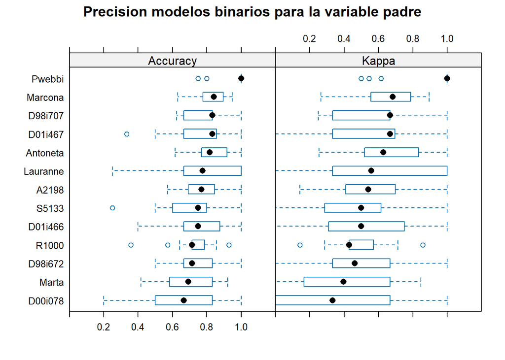

```r
bwplot(modelos.resamplep, main="Precision modelos binarios para la variable padre",  xlim = c(0, 1.2))
```

```r
difestp <- diff(modelos.resamplep, adjustment = "none")
summary(difestp)
```

```
##
## Call:
## summary.diff.resamples(object = difestp)
##
## Upper diagonal: estimates of the difference
## Lower diagonal: p-value for H0: difference = 0
##
## Accuracy
##          Marcona   R1000     A2198     Antoneta  Marta     D01i466   D98i672
## Marcona             0.100515  0.056632  0.007487  0.127145  0.088095  0.070674
## R1000    0.0007212           -0.043883 -0.093028  0.026630 -0.012421 -0.029841
## A2198    0.0245204 0.1955854           -0.049145  0.070513  0.031462  0.014042
## Antoneta 0.7471648 0.0050557 0.0331841            0.119658  0.080607  0.063187
## Marta    8.412e-05 0.3272746 0.0516274 0.0006556           -0.039051 -0.056471
## D01i466  0.0238087 0.7123092 0.2938052 0.0124530 0.2679248           -0.017421
## D98i672  0.0306666 0.4246326 0.6804260 0.0495456 0.0594197 0.6475063
## D01i467  0.1294494 0.1764932 0.9389122 0.2020173 0.0480588 0.3351533 0.6449647
## D00i078  0.0037284 0.3709430 0.0632179 0.0034425 0.7042898 0.2743830 0.1203062
## D98i707  0.3494870 0.0315723 0.2196310 0.5217895 0.0029791 0.0739685 0.1298836
## Lauranne 0.1816220 0.2490515 0.8898405 0.3094733 0.1149799 0.4892419 0.7212021
## Pwebbi   1.193e-06 1.656e-10 3.149e-10 9.647e-08 4.050e-10 4.779e-08 3.355e-07
## S5133    0.0113737 0.9572797 0.1905750 0.0274526 0.5370257 0.7442599 0.3904792
##          D01i467   D00i078   D98i707   Lauranne  Pwebbi    S5133
## Marcona   0.054007  0.145595  0.023650  0.050595 -0.137183  0.102817
## R1000    -0.046508  0.045079 -0.076865 -0.049921 -0.237698  0.002302
## A2198    -0.002625  0.088962 -0.032982 -0.006038 -0.193816  0.046184
## Antoneta  0.046520  0.138107  0.016163  0.043107 -0.144670  0.095330
## Marta    -0.073138  0.018449 -0.103495 -0.076551 -0.264328 -0.024328
## D01i466  -0.034087  0.057500 -0.064444 -0.037500 -0.225278  0.014722
## D98i672  -0.016667  0.074921 -0.047024 -0.020079 -0.207857  0.032143
## D01i467             0.091587 -0.030357 -0.003413 -0.191190  0.048810
## D00i078  0.0518124           -0.121944 -0.095000 -0.282778 -0.042778
## D98i707  0.4532270 0.0056186            0.026944 -0.160833  0.079167
## Lauranne 0.9509788 0.1214486 0.5779190           -0.187778  0.052222
## Pwebbi   3.476e-06 6.091e-08 3.035e-07 6.844e-05            0.240000
## S5133    0.3148734 0.3691026 0.0213474 0.3217077 7.680e-08
##
## Kappa
##          Marcona   R1000      A2198      Antoneta   Marta      D01i466
## Marcona             2.023e-01  1.146e-01  1.575e-02  2.551e-01  1.770e-01
```

[output cut: 25 more lines]

```
## S5133    0.4166844  0.3396889  0.3092581  0.0245537  0.3156282  1.152e-07
##          S5133
## Marcona   2.022e-01
## R1000    -9.411e-05
## A2198     8.759e-02
## Antoneta  1.864e-01
## Marta    -5.289e-02
## D01i466   2.513e-02
## D98i672   6.040e-02
## D01i467   9.257e-02
## D00i078  -9.841e-02
## D98i707   1.529e-01
## Lauranne  1.057e-01
## Pwebbi    4.730e-01
## S5133
```